# Investigating the coherency between logical relationships and gene expressions for each connected gene pair in the signaling networks

# 7.Two Edge Subgraphs

$~$  
$~$

```r
load("Two Edge Subgraphs KEGG GEO.RData")
```

The following code shows if there is any loop among the eligible edges.

```r
logic=c()
for(i in Eligibles){
  logic[i] = edgelist[i,2]==edgelist[i,3]
}
idxloop = which(logic)
edgelist[idxloop,]
```

```
## [1] ID               Gene1            Gene2            Interaction type
## <0 rows> (or 0-length row.names)
```

```r
# There is no loop
```

$~$

Edges which has been participated in two-edge subgraphs are saved at **twoEdges** edgelist. the indices of these edges are stored at **idxTWOedges** object.

```r
idxTWOedges = list()
for(i in Eligibles){
  a = edgelist[i,2]
  b = edgelist[i,3]

  index = which(edgelist[,2] == b & edgelist[,3] == a)
  if(length(index) > 0){idxTWOedges[[i]] = c(i,index)}

}
idxTWOedges = unlist(idxTWOedges)

length(idxTWOedges)
twoEdges=edgelist[idxTWOedges,]
sum(duplicated(twoEdges))
sum(duplicated(edgelist[2:4]))

twoEdges = twoEdges[!duplicated(twoEdges),]
idxTWOedges = rownames(twoEdges)
idxTWOedges = as.numeric(idxTWOedges)
```

$~$

```r
length(idxTWOedges)
```

```
## [1] 314
```

```r
tail(twoEdges)
```

```
##           ID  Gene1  Gene2 Interaction type idxTWOedges
## 20272 E20272 CDKN1B  CCND2       inhibition       20272
## 25769 E25769  CCND2 CDKN1B       inhibition       25769
## 20273 E20273 CDKN1B  CCND3       inhibition       20273
## 25770 E25770  CCND3 CDKN1B       inhibition       25770
## 21710 E21710 CSNK1E  WWTR1       inhibition       21710
## 21726 E21726  WWTR1 CSNK1E       inhibition       21726
```

```r
head(twoEdges)
```

```
##           ID  Gene1  Gene2 Interaction type idxTWOedges
## 21    E00021   EGFR    SRC       activation          21
## 16566 E16566    SRC   EGFR       activation       16566
## 264   E00264   PTK2 PIK3CA       activation         264
## 4387  E04387 PIK3CA   PTK2       activation        4387
## 265   E00265   PTK2 PIK3CB       activation         265
## 4388  E04388 PIK3CB   PTK2       activation        4388
```

$~$

Two-edge subgraphs are stored at **two.edge.subgraphs** object. This table is a **bisection edgelist**, and it contains columns which determine the indices of edges that has been participated in two edge subgraphs. Each row of the table presents a two-edge subgraph (Figure8).

[figure not shown]

Figure8: The bisection edgelist

```r
twoEdges$idxTWOedges = idxTWOedges

which(duplicated(edgelist[,2:4]))

index = seq(1 , length(idxTWOedges) , by = 2 )

two.edge.subgraphs = cbind(twoEdges[index,] , twoEdges[index + 1 ,])
```

$~$

DNFBL-two-edge subgrphs are stored at the bisection edgelist called **DNFBL**, DPFBL1-two-edge subgrphs are stored at the bisection edgellist called **DPFBL1** and DPFBL2-two-edge subgrphs are stored at the bisection edgellist called **DPFBL2** (Tables 1 and 2).

```r
idxDNFBL.1 = which(two.edge.subgraphs[,4]=="activation" & two.edge.subgraphs[,9]=="inhibition")
DNFBL.1 = two.edge.subgraphs[idxDNFBL.1,]
```

```r
length(DNFBL.1[,1])
```

```
## [1] 20
```

```r
head(DNFBL.1)
```

```
##          ID   Gene1     Gene2 Interaction type idxTWOedges     ID     Gene1
## 1741 E01741    RAC1      RHOA       activation        1741 E25247      RHOA
## 1742 E01742    RAC2      RHOA       activation        1742 E25248      RHOA
## 1743 E01743    RAC3      RHOA       activation        1743 E25249      RHOA
## 2900 E02900  PRKACB   PPP1R1B       activation        2900 E25642   PPP1R1B
## 3107 E03107 TNFSF11 TNFRSF11B       activation        3107 E21675 TNFRSF11B
## 4885 E04885    INSR    PTPN11       activation        4885 E25571    PTPN11
##        Gene2 Interaction type idxTWOedges
## 1741    RAC1       inhibition       25247
## 1742    RAC2       inhibition       25248
## 1743    RAC3       inhibition       25249
## 2900  PRKACB       inhibition       25642
## 3107 TNFSF11       inhibition       21675
## 4885    INSR       inhibition       25571
```

```r
idxDNFBL.2 = which(two.edge.subgraphs[,4]=="inhibition" & two.edge.subgraphs[,9]=="activation")
DNFBL.2 = two.edge.subgraphs[idxDNFBL.2,]
```

```r
DNFBL = rbind(DNFBL.1 , DNFBL.2)
idxDNFBL = c(idxDNFBL.1,idxDNFBL.2)
```

$~$  
$~$

```r
idxDPFBL1 = which(two.edge.subgraphs[,4]=="activation" & two.edge.subgraphs[,9]=="activation")
DPFBL1 = two.edge.subgraphs[idxDPFBL1,]
```

```r
length(DPFBL1[,1])
```

```
## [1] 125
```

```r
head(DPFBL1)
```

```
##         ID Gene1  Gene2 Interaction type idxTWOedges     ID  Gene1 Gene2
## 21  E00021  EGFR    SRC       activation          21 E16566    SRC  EGFR
## 264 E00264  PTK2 PIK3CA       activation         264 E04387 PIK3CA  PTK2
## 265 E00265  PTK2 PIK3CB       activation         265 E04388 PIK3CB  PTK2
## 266 E00266  PTK2 PIK3CD       activation         266 E04389 PIK3CD  PTK2
## 267 E00267  PTK2 PIK3R1       activation         267 E04390 PIK3R1  PTK2
## 268 E00268  PTK2 PIK3R2       activation         268 E04391 PIK3R2  PTK2
##     Interaction type idxTWOedges
## 21        activation       16566
## 264       activation        4387
## 265       activation        4388
## 266       activation        4389
## 267       activation        4390
## 268       activation        4391
```

$~$  
$~$

```r
idxDPFBL2 = which(two.edge.subgraphs[,4]=="inhibition" & two.edge.subgraphs[,9]=="inhibition")
DPFBL2 = two.edge.subgraphs[idxDPFBL2,]
```

```r
length(DPFBL2[,1])
```

```
## [1] 12
```

```r
head(DPFBL2)
```

```
##           ID  Gene1  Gene2 Interaction type idxTWOedges     ID  Gene1  Gene2
## 21354 E21354   GLI1   GLI3       inhibition       21354 E21350   GLI3   GLI1
## 19192 E19192   BCL2    BAX       inhibition       19192 E26437    BAX   BCL2
## 19202 E19202   BCL2    BAD       inhibition       19202 E19216    BAD   BCL2
## 19217 E19217 BCL2L1   BAK1       inhibition       19217 E25805   BAK1 BCL2L1
## 19841 E19841   CDK2 CDKN1B       inhibition       19841 E19850 CDKN1B   CDK2
## 19842 E19842   CDK2 CDKN1C       inhibition       19842 E19851 CDKN1C   CDK2
##       Interaction type idxTWOedges
## 21354       inhibition       21350
## 19192       inhibition       26437
## 19202       inhibition       19216
## 19217       inhibition       25805
## 19841       inhibition       19850
## 19842       inhibition       19851
```

$~$  
$~$

### 7.1.Computing the number of edges constructing in three kinds of two-edge subgraphs

$~$

### DNFBL

```r
index = c(DNFBL[,5],DNFBL[,10])


DNFBL.pval.cor1 = 0
DNFBL.pval.cor.NA = 0
DNFBL.pval.cor2 = 0



for(i in index){
  logic =c()
  if(SignalingNet[[i]]$length > 1){

    for(j in 1:SignalingNet[[i]]$length){
      logic[j]= !any(unlist(lapply(SignalingNet[[i]]$corAnalysis[[j]],is.na)))
    }
    if(all(logic)){
      logic1 = c()
      logic2 = c()
      for(j in 1:SignalingNet[[i]]$length){

        logic1[j] = SignalingNet[[i]]$corAnalysis[[j]]$pearson$adjusted.pearsonpval < 0.05 & SignalingNet[[i]]$corAnalysis[[j]]$pearson$pearsoncor > 0
        logic2[j] = SignalingNet[[i]]$corAnalysis[[j]]$pearson$adjusted.pearsonpval < 0.05 & SignalingNet[[i]]$corAnalysis[[j]]$pearson$pearsoncor < 0
      }
      if(all(logic1)) {DNFBL.pval.cor1=DNFBL.pval.cor1+1}
      if(all(logic2)) {DNFBL.pval.cor2=DNFBL.pval.cor2+1}
    }
  } else{
    if(!any(unlist(lapply(SignalingNet[[i]]$corAnalysis,is.na)))){
      a = SignalingNet[[i]]$corAnalysis$pearson$adjusted.pearsonpval < 0.05 & SignalingNet[[i]]$corAnalysis$pearson$pearsoncor > 0
      b = SignalingNet[[i]]$corAnalysis$pearson$adjusted.pearsonpval < 0.05 & SignalingNet[[i]]$corAnalysis$pearson$pearsoncor < 0
      if(a){DNFBL.pval.cor1=DNFBL.pval.cor1+1}
      if(b){DNFBL.pval.cor2=DNFBL.pval.cor2+1}
    }
  }
}




for(i in index){
  logic = c()
  if(SignalingNet[[i]]$length > 1){

    for(j in 1:SignalingNet[[i]]$length){

      logic[j]=any(unlist(lapply(SignalingNet[[i]]$corAnalysis[[j]],is.na))) | SignalingNet[[i]]$corAnalysis[[j]]$pearson$adjusted.pearsonpval > 0.05
    }
    if(all(logic)){ DNFBL.pval.cor.NA = DNFBL.pval.cor.NA + 1 }

  }else{ if(any(unlist(lapply(SignalingNet[[i]]$corAnalysis,is.na)))| SignalingNet[[i]]$corAnalysis$pearson$adjusted.pearsonpval > 0.05){
    index.pval.cor.NA = DNFBL.pval.cor.NA + 1}
  }
}
```

```r
DNFBL.pval.cor1
```

```
## [1] 0
```

```r
DNFBL.pval.cor.NA
```

```
## [1] 10
```

```r
DNFBL.pval.cor2
```

```
## [1] 3
```

```r
length(DNFBL[,1]) * 2 - c(DNFBL.pval.cor1 + DNFBL.pval.cor.NA + DNFBL.pval.cor2)
```

```
## [1] 27
```

$~$  
$~$

### DPFBL1

```r
index = c(DPFBL1[,5] , DPFBL1[,10])



DPFBL1.pval.cor1 = 0
DPFBL1.pval.cor.NA = 0
DPFBL1.pval.cor2 = 0



for(i in index){
  logic =c()
  if(SignalingNet[[i]]$length > 1){

    for(j in 1:SignalingNet[[i]]$length){
      logic[j]=(!(class(SignalingNet[[i]]$corAnalysis[[j]]) == "logical" | any(is.na(unlist(SignalingNet[[i]]$corAnalysis[[j]])))))
    }
    if(all(logic)){
      logic1 = c()
      logic2 = c()
      for(j in 1:SignalingNet[[i]]$length){

        logic1[j] = SignalingNet[[i]]$corAnalysis[[j]]$pearson$adjusted.pearsonpval < 0.05 & SignalingNet[[i]]$corAnalysis[[j]]$pearson$pearsoncor > 0
        logic2[j] = SignalingNet[[i]]$corAnalysis[[j]]$pearson$adjusted.pearsonpval < 0.05 & SignalingNet[[i]]$corAnalysis[[j]]$pearson$pearsoncor < 0
      }
      if(all(logic1)) {DPFBL1.pval.cor1=DPFBL1.pval.cor1+1}
      if(all(logic2)) {DPFBL1.pval.cor2=DPFBL1.pval.cor2+1}
    }
  } else if(SignalingNet[[i]]$length == 1) {
    if(!(class(SignalingNet[[i]]$corAnalysis) == "logical" | any(is.na(unlist(SignalingNet[[i]]$corAnalysis))))){
      a = SignalingNet[[i]]$corAnalysis$pearson$adjusted.pearsonpval < 0.05 & SignalingNet[[i]]$corAnalysis$pearson$pearsoncor > 0
      b = SignalingNet[[i]]$corAnalysis$pearson$adjusted.pearsonpval < 0.05 & SignalingNet[[i]]$corAnalysis$pearson$pearsoncor < 0
      if(a){DPFBL1.pval.cor1=DPFBL1.pval.cor1+1}
      if(b){DPFBL1.pval.cor2=DPFBL1.pval.cor2+1}
    }
  }
}





for(i in index){
  logic =c()
  if(SignalingNet[[i]]$length > 1){
    for(j in 1:SignalingNet[[i]]$length){
      logic[j]=!class(SignalingNet[[i]]$corAnalysis[[j]]) == "logical"
    }
    if(all(logic)){
      logic1 =c()
      for(j in 1:SignalingNet[[i]]$length){
        logic1[j]= is.na(SignalingNet[[i]]$corAnalysis[[j]]$pearson$adjusted.pearsonpval) | SignalingNet[[i]]$corAnalysis[[j]]$pearson$adjusted.pearsonpval > 0.05
      }
      if(all(logic1)){DPFBL1.pval.cor.NA = DPFBL1.pval.cor.NA+1}
    }

  } else {
    if(!class(SignalingNet[[i]]$corAnalysis) == "logical"){
      a = is.na(SignalingNet[[i]]$corAnalysis$pearson$adjusted.pearsonpval) | SignalingNet[[i]]$corAnalysis$pearson$adjusted.pearsonpval > 0.05
      if(a){DPFBL1.pval.cor.NA=DPFBL1.pval.cor.NA+1}
    }
  }
}
```

```r
DPFBL1.pval.cor1
```

```
## [1] 34
```

```r
DPFBL1.pval.cor.NA
```

```
## [1] 85
```

```r
DPFBL1.pval.cor2
```

```
## [1] 6
```

```r
length(DPFBL1[,1]) * 2 - c(DPFBL1.pval.cor1 + DPFBL1.pval.cor.NA + DPFBL1.pval.cor2)
```

```
## [1] 125
```

$~$  
$~$

### DPFBL2

```r
index = c(DPFBL2[,5] , DPFBL2[,10])


DPFBL2.pval.cor1 = 0
DPFBL2.pval.cor.NA = 0
DPFBL2.pval.cor2 = 0



for(i in index){
  logic =c()
  if(SignalingNet[[i]]$length > 1){

    for(j in 1:SignalingNet[[i]]$length){
      logic[j]=(!(class(SignalingNet[[i]]$corAnalysis[[j]]) == "logical" | any(is.na(unlist(SignalingNet[[i]]$corAnalysis[[j]])))))
    }
    if(all(logic)){
      logic1 = c()
      logic2 = c()
      for(j in 1:SignalingNet[[i]]$length){

        logic1[j] = SignalingNet[[i]]$corAnalysis[[j]]$pearson$adjusted.pearsonpval < 0.05 & SignalingNet[[i]]$corAnalysis[[j]]$pearson$pearsoncor > 0
        logic2[j] = SignalingNet[[i]]$corAnalysis[[j]]$pearson$adjusted.pearsonpval < 0.05 & SignalingNet[[i]]$corAnalysis[[j]]$pearson$pearsoncor < 0
      }
      if(all(logic1)) {DPFBL2.pval.cor1=DPFBL2.pval.cor1+1}
      if(all(logic2)) {DPFBL2.pval.cor2=DPFBL2.pval.cor2+1}
    }
  } else if(SignalingNet[[i]]$length == 1) {
    if(!(class(SignalingNet[[i]]$corAnalysis) == "logical" | any(is.na(unlist(SignalingNet[[i]]$corAnalysis))))){
      a = SignalingNet[[i]]$corAnalysis$pearson$adjusted.pearsonpval < 0.05 & SignalingNet[[i]]$corAnalysis$pearson$pearsoncor > 0
      b = SignalingNet[[i]]$corAnalysis$pearson$adjusted.pearsonpval < 0.05 & SignalingNet[[i]]$corAnalysis$pearson$pearsoncor < 0
      if(a){DPFBL2.pval.cor1=DPFBL2.pval.cor1+1}
      if(b){DPFBL2.pval.cor2=DPFBL2.pval.cor2+1}
    }
  }
}





for(i in index){
  logic =c()
  if(SignalingNet[[i]]$length > 1){
    for(j in 1:SignalingNet[[i]]$length){
      logic[j]=!class(SignalingNet[[i]]$corAnalysis[[j]]) == "logical"
    }
    if(all(logic)){
      logic1 =c()
      for(j in 1:SignalingNet[[i]]$length){
        logic1[j]= is.na(SignalingNet[[i]]$corAnalysis[[j]]$pearson$adjusted.pearsonpval) | SignalingNet[[i]]$corAnalysis[[j]]$pearson$adjusted.pearsonpval > 0.05
      }
      if(all(logic1)){DPFBL2.pval.cor.NA = DPFBL2.pval.cor.NA+1}
    }

  } else {
    if(!class(SignalingNet[[i]]$corAnalysis) == "logical"){
      a = is.na(SignalingNet[[i]]$corAnalysis$pearson$adjusted.pearsonpval) | SignalingNet[[i]]$corAnalysis$pearson$adjusted.pearsonpval > 0.05
      if(a){DPFBL2.pval.cor.NA=DPFBL2.pval.cor.NA+1}
    }
  }
}
```

```r
DPFBL2.pval.cor1
```

```
## [1] 0
```

```r
DPFBL2.pval.cor.NA
```

```
## [1] 10
```

```r
DPFBL2.pval.cor2
```

```
## [1] 0
```

```r
length(DPFBL2[,1]) * 2 - (DPFBL2.pval.cor1 + DPFBL2.pval.cor.NA + DPFBL2.pval.cor2)
```

```
## [1] 14
```

$~$

$~$

$~$

$~$

$~$

$~$

$~$

$~$

# 8.Multiple Edge subgraphs

To compute the number of edges which participate in multiple-edge subgraphs, an edgelist is created from eligible edges called **shortEdgelist**.

```r
library(igraph)
```

```r
shortEdgelist = edgelist[Eligibles,]

shortEdgelist[which(shortEdgelist[,4] == "activation"),4] = 1
shortEdgelist[which(shortEdgelist[,4] == "inhibition"),4] = -1
```

$~$

A weighted graph was created from shortEdgelist object, and -1 was assigned to inhibitions and 1 was assigned to activations as weights. Then, the largest component of the eligibile edges in the graph was extracted called **weighted.giant.component**. We changed this object into an adjacency matrix called **WadjaMatrix**. The same processes were done for non-weighted adjacency matrix and an object called **none.weighted.giant.component** was created. Then, **AdjaMatrix** object was created from that object. The diameter of the two giant components was computed and using matrix self-multiplication, the number of edges which are engaged in 8 kinds of multiple-edge subgraphs was computed (Table1 and Table2).

$~$  
$~$

If the edge i in the edgelist is activation and the entity between the gene pair in one of the weighted matrices equals to their unweighted counterparts while the entities are not zero or NA, this edge is engaged in MFFL1 or MPFBL1 subgraphs.

If the edge i in the edgelist is inhibition and the entity between the gene pair in one of the weighted matrices equals to their unweighted counterparts while the entities are not zero or NA, this edge is engaged in MNFFL2 or MNFBL2 subgraphs.

If the edge i in the edgelist is activation and the entity between the gene pair in one of the weighted matrices does not equal to their unweighted counterparts while the entities are not zero or NA, this edge is engaged in MNFBL1 or MNFFL1 subgraphs.

If the edge i in the edgelist is inhibition and the entity between the gene pair in one of the weighted matrices does not equal to their unweighted counterparts while the entities are not zero or NA, this edge is engaged in MFFL2 or MPFBL2 subgraphs.

```r
w = as.numeric(shortEdgelist[,4])
shortEdgelist = as.matrix(shortEdgelist)

g = graph_from_edgelist(shortEdgelist[,2:3] , directed = T)
E(g)$weights = w
```

$~$

```r
shortEdgelistGenes = unique(c(shortEdgelist[,2] , c(shortEdgelist[,3])))

c= components(g)

weighted.giant.component = induced.subgraph(g , which(c$membership ==  1))
```

```r
weighted.giant.component
```

```
## IGRAPH e173162 DN-- 2549 15718 --
## + attr: name (v/c), weights (e/n)
## + edges from e173162 (vertex names):
##  [1] EGF  ->EGFR   TGFA ->EGFR   HGF  ->MET    MET  ->ERBB3  IGF1 ->IGF1R
##  [6] VEGFA->KDR    PDGFA->PDGFRA PDGFB->PDGFRA PDGFC->PDGFRA PDGFD->PDGFRA
## [11] PDGFA->PDGFRB PDGFB->PDGFRB PDGFC->PDGFRB PDGFD->PDGFRB FGF2 ->FGFR3
## [16] FGF2 ->FGFR2  GAS6 ->AXL    IL6  ->IL6R   EGFR ->JAK1   EGFR ->JAK2
## [21] EGFR ->SRC    EGFR ->GAB1   EGFR ->PLCG1  EGFR ->PLCG2  EGFR ->SHC2
## [26] EGFR ->SHC4   EGFR ->SHC3   EGFR ->SHC1   MET  ->JAK1   MET  ->JAK2
## [31] MET  ->SRC    MET  ->GAB1   MET  ->PLCG1  MET  ->PLCG2  MET  ->SHC2
## [36] MET  ->SHC4   MET  ->SHC3   MET  ->SHC1   IGF1R->JAK1   IGF1R->JAK2
## + ... omitted several edges
```

```r
is.connected(weighted.giant.component)
```

```
## [1] TRUE
```

```r
WadjMatrix = as_adjacency_matrix(weighted.giant.component , attr = "weights")

WadjMatrix = as.matrix(WadjMatrix)
```

```r
diameter(weighted.giant.component)
```

```
## [1] 17
```

$~$  
$~$

```r
Wmatpower2 = WadjMatrix  %*% WadjMatrix

Wmatpower3 = Wmatpower2  %*% WadjMatrix

Wmatpower4 = Wmatpower3  %*% WadjMatrix

Wmatpower5 = Wmatpower4  %*% WadjMatrix

Wmatpower6 = Wmatpower5 %*% WadjMatrix

Wmatpower7 = Wmatpower6 %*% WadjMatrix

Wmatpower8 = Wmatpower7 %*% WadjMatrix

Wmatpower9 = Wmatpower8  %*% WadjMatrix

Wmatpower10 = Wmatpower9  %*% WadjMatrix

Wmatpower11 = Wmatpower10  %*% WadjMatrix

Wmatpower12 = Wmatpower11  %*% WadjMatrix

Wmatpower13 = Wmatpower12 %*% WadjMatrix

Wmatpower14 = Wmatpower13 %*% WadjMatrix

Wmatpower15 = Wmatpower14  %*% WadjMatrix

Wmatpower16 = Wmatpower15  %*% WadjMatrix

Wmatpower17 = Wmatpower16  %*% WadjMatrix
```

$~$  
$~$

```r
g1 = graph_from_edgelist(shortEdgelist[,2:3] , directed = T)

c= components(g1)

none.weighted.giant.component = induced.subgraph(g1 , which(c$membership ==  1))
```

```r
none.weighted.giant.component
```

```
## IGRAPH 4d382e2 DN-- 2549 15718 --
## + attr: name (v/c)
## + edges from 4d382e2 (vertex names):
##  [1] EGF  ->EGFR   TGFA ->EGFR   HGF  ->MET    MET  ->ERBB3  IGF1 ->IGF1R
##  [6] VEGFA->KDR    PDGFA->PDGFRA PDGFB->PDGFRA PDGFC->PDGFRA PDGFD->PDGFRA
## [11] PDGFA->PDGFRB PDGFB->PDGFRB PDGFC->PDGFRB PDGFD->PDGFRB FGF2 ->FGFR3
## [16] FGF2 ->FGFR2  GAS6 ->AXL    IL6  ->IL6R   EGFR ->JAK1   EGFR ->JAK2
## [21] EGFR ->SRC    EGFR ->GAB1   EGFR ->PLCG1  EGFR ->PLCG2  EGFR ->SHC2
## [26] EGFR ->SHC4   EGFR ->SHC3   EGFR ->SHC1   MET  ->JAK1   MET  ->JAK2
## [31] MET  ->SRC    MET  ->GAB1   MET  ->PLCG1  MET  ->PLCG2  MET  ->SHC2
## [36] MET  ->SHC4   MET  ->SHC3   MET  ->SHC1   IGF1R->JAK1   IGF1R->JAK2
## + ... omitted several edges
```

```r
is.connected(none.weighted.giant.component)
```

```
## [1] TRUE
```

```r
AdjMatrix = as_adjacency_matrix(none.weighted.giant.component)

AdjMatrix = as.matrix(AdjMatrix)
```

```r
diameter(none.weighted.giant.component)
```

```
## [1] 17
```

$~$

```r
matpower2 = AdjMatrix  %*% AdjMatrix

matpower3 = matpower2  %*% AdjMatrix

matpower4 = matpower3  %*% AdjMatrix

matpower5 = matpower4  %*% AdjMatrix

matpower6 = matpower5 %*% AdjMatrix

matpower7 = matpower6 %*% AdjMatrix

matpower8 = matpower7 %*% AdjMatrix

matpower9 = matpower8  %*% AdjMatrix

matpower10 = matpower9  %*% AdjMatrix

matpower11 = matpower10  %*% AdjMatrix

matpower12 = matpower11  %*% AdjMatrix

matpower13 = matpower12 %*% AdjMatrix

matpower14 = matpower13 %*% AdjMatrix

matpower15 = matpower14  %*% AdjMatrix

matpower16 = matpower15  %*% AdjMatrix

matpower17 = matpower16  %*% AdjMatrix
```

$~$  
$~$

**listAdj1** object is a large list containing matrices as the same dimension as the adjacency matrices. This list contains 16 matrices, and Each matrix is representative of one of the powered matrices.

```r
Apower = matrix(0 , 2549 , 2549)
colnames(Apower) = colnames(AdjMatrix)
rownames(Apower) = rownames(AdjMatrix)
listAdj1 = list(Apower2 = Apower,
Apower3 = Apower,
Apower4 = Apower,
Apower5 = Apower,
Apower6 = Apower,
Apower7 = Apower,
Apower8 = Apower,
Apower9 = Apower,
Apower10 = Apower,
Apower11 = Apower,
Apower12 = Apower,
Apower13 = Apower,
Apower14 = Apower,
Apower15 = Apower,
Apower16 = Apower,
Apower17 = Apower
)
```

$~$

Before computing the number of edges which participate in multiple-edge subgraphs, the following algorithms are required to be applied: If WmatpowerX[i,j] == matpowerX[i,j], we put the value of WmatpowerX[i,j] at the ApowerX[i,j] in **listAdj1** list. Otherwise, we put NA. After that, the number of edges which take part in “MPFBL1”, “MNFBL2”, “MFFL1” and “MNFFL2” multiple-edge subgraphs are computed. For the other multiple-edge subgraphs called “MNFBL1”, “MPFBL2”, “MFFL2” and “MNFFL1”, If WmatpowerX[i,j] != matpowerX[i,j], we put the value of WmatpowerX[i,j] at the ApowerX[i,j] in **listAdj2** list. Otherwise, we put NA.

```r
for(i in 1:length(AdjMatrix[,1])){

for(j in 1:length(AdjMatrix[1,])){

if(Wmatpower2[i,j] == matpower2[i,j]){
  listAdj1$Apower2[i,j] = Wmatpower2[i,j]
} else { listAdj1$Apower2[i,j] = NA }


if(Wmatpower3[i,j] == matpower3[i,j]){
  listAdj1$Apower3[i,j] = Wmatpower3[i,j]
} else { listAdj1$Apower3[i,j] = NA }


if(Wmatpower4[i,j] == matpower4[i,j]){
  listAdj1$Apower4[i,j] = Wmatpower4[i,j]
} else { listAdj1$Apower4[i,j] = NA }


if(Wmatpower5[i,j] == matpower5[i,j]){
  listAdj1$Apower5[i,j] = Wmatpower5[i,j]
} else { listAdj1$Apower5[i,j] = NA }


if(Wmatpower6[i,j] == matpower6[i,j]){
  listAdj1$Apower6[i,j] = Wmatpower6[i,j]
} else { listAdj1$Apower6[i,j] = NA }


if(Wmatpower7[i,j] == matpower7[i,j]){
  listAdj1$Apower7[i,j] = Wmatpower7[i,j]
} else { listAdj1$Apower7[i,j] = NA }


if(Wmatpower8[i,j] == matpower8[i,j]){
  listAdj1$Apower8[i,j] = Wmatpower8[i,j]
} else { listAdj1$Apower8[i,j] = NA }


if(Wmatpower9[i,j] == matpower9[i,j]){
  listAdj1$Apower9[i,j] = Wmatpower9[i,j]
} else { listAdj1$Apower9[i,j] = NA }


if(Wmatpower10[i,j] == matpower10[i,j]){
  listAdj1$Apower10[i,j] = Wmatpower10[i,j]
} else { listAdj1$Apower10[i,j] = NA }


if(Wmatpower11[i,j] == matpower11[i,j]){
  listAdj1$Apower11[i,j] = Wmatpower11[i,j]
} else { listAdj1$Apower11[i,j] = NA }


if(Wmatpower12[i,j] == matpower12[i,j]){
  listAdj1$Apower12[i,j] = Wmatpower12[i,j]
} else { listAdj1$Apower12[i,j] = NA }


if(Wmatpower13[i,j] == matpower13[i,j]){
  listAdj1$Apower13[i,j] = Wmatpower13[i,j]
} else { listAdj1$Apower13[i,j] = NA }


if(Wmatpower14[i,j] == matpower14[i,j]){
  listAdj1$Apower14[i,j] = Wmatpower14[i,j]
} else { listAdj1$Apower14[i,j] = NA }


if(Wmatpower15[i,j] == matpower15[i,j]){
  listAdj1$Apower15[i,j] = Wmatpower15[i,j]
} else { listAdj1$Apower15[i,j] = NA }


if(Wmatpower16[i,j] == matpower16[i,j]){
  listAdj1$Apower16[i,j] = Wmatpower16[i,j]
} else { listAdj1$Apower16[i,j] = NA }


if(Wmatpower17[i,j] == matpower17[i,j]){
  listAdj1$Apower17[i,j] = Wmatpower17[i,j]
} else { listAdj1$Apower17[i,j] = NA }

}
  # print(i)
}
```

$~$

```r
Apower = matrix(0 , 2549 , 2549)
colnames(Apower) = colnames(AdjMatrix)
rownames(Apower) = rownames(AdjMatrix)
listAdj2 = list(Apower2 = Apower,
               Apower3 = Apower,
               Apower4 = Apower,
               Apower5 = Apower,
               Apower6 = Apower,
               Apower7 = Apower,
               Apower8 = Apower,
               Apower9 = Apower,
               Apower10 = Apower,
               Apower11 = Apower,
               Apower12 = Apower,
               Apower13 = Apower,
               Apower14 = Apower,
               Apower15 = Apower,
               Apower16 = Apower,
               Apower17 = Apower
)
```

```r
for(i in 1:length(AdjMatrix[,1])){

  for(j in 1:length(AdjMatrix[1,])){

    if(Wmatpower2[i,j] != matpower2[i,j]){
      listAdj2$Apower2[i,j] = Wmatpower2[i,j]
    } else { listAdj2$Apower2[i,j] = NA }


    if(Wmatpower3[i,j] != matpower3[i,j]){
      listAdj2$Apower3[i,j] = Wmatpower3[i,j]
    } else { listAdj2$Apower3[i,j] = NA }


    if(Wmatpower4[i,j] != matpower4[i,j]){
      listAdj2$Apower4[i,j] = Wmatpower4[i,j]
    } else { listAdj2$Apower4[i,j] = NA }


    if(Wmatpower5[i,j] != matpower5[i,j]){
      listAdj2$Apower5[i,j] = Wmatpower5[i,j]
    } else { listAdj2$Apower5[i,j] = NA }


    if(Wmatpower6[i,j] != matpower6[i,j]){
      listAdj2$Apower6[i,j] = Wmatpower6[i,j]
    } else { listAdj2$Apower6[i,j] = NA }


    if(Wmatpower7[i,j] != matpower7[i,j]){
      listAdj2$Apower7[i,j] = Wmatpower7[i,j]
    } else { listAdj2$Apower7[i,j] = NA }


    if(Wmatpower8[i,j] != matpower8[i,j]){
      listAdj2$Apower8[i,j] = Wmatpower8[i,j]
    } else { listAdj2$Apower8[i,j] = NA }


    if(Wmatpower9[i,j] != matpower9[i,j]){
      listAdj2$Apower9[i,j] = Wmatpower9[i,j]
    } else { listAdj2$Apower9[i,j] = NA }


    if(Wmatpower10[i,j] != matpower10[i,j]){
      listAdj2$Apower10[i,j] = Wmatpower10[i,j]
    } else { listAdj2$Apower10[i,j] = NA }


    if(Wmatpower11[i,j] != matpower11[i,j]){
      listAdj2$Apower11[i,j] = Wmatpower11[i,j]
    } else { listAdj2$Apower11[i,j] = NA }


    if(Wmatpower12[i,j] != matpower12[i,j]){
      listAdj2$Apower12[i,j] = Wmatpower12[i,j]
    } else { listAdj2$Apower12[i,j] = NA }


    if(Wmatpower13[i,j] != matpower13[i,j]){
      listAdj2$Apower13[i,j] = Wmatpower13[i,j]
    } else { listAdj2$Apower13[i,j] = NA }


    if(Wmatpower14[i,j] != matpower14[i,j]){
      listAdj2$Apower14[i,j] = Wmatpower14[i,j]
    } else { listAdj2$Apower14[i,j] = NA }


    if(Wmatpower15[i,j] != matpower15[i,j]){
      listAdj2$Apower15[i,j] = Wmatpower15[i,j]
    } else { listAdj2$Apower15[i,j] = NA }


    if(Wmatpower16[i,j] != matpower16[i,j]){
      listAdj2$Apower16[i,j] = Wmatpower16[i,j]
    } else { listAdj2$Apower16[i,j] = NA }


    if(Wmatpower17[i,j] != matpower17[i,j]){
      listAdj2$Apower17[i,j] = Wmatpower17[i,j]
    } else { listAdj2$Apower17[i,j] = NA }

  }

}
```

$~$

Using the following code, the indices of the giant component edges in the **KEGG edgelist** are found, and they are stored at **commonIndex** object.

```r
m = as_edgelist(weighted.giant.component)
m = as.data.frame(m , stringsAsFactors = F)
e = edgelist[,2:3]


index.of.rows.in.x.that.are.in.y  <- function(x,y)
{
  x.vec <- apply(x, 1, paste, collapse = "")
  y.vec <- apply(y, 1, paste, collapse = "")
  index = x.vec %in% y.vec
  return(which(index))
}
commonIndex = index.of.rows.in.x.that.are.in.y(e,m)
```

$~$  
$~$

### 8.1.Computing the number of edges participating in MPFBL1, MNFBL2, MFFL1 and MNFFL2 multiple-edge subgraphs

$~$

The indices of edges taking part in MFFL1 subgraph are saved at **idxMFFL1** object through the following code.

```r
MFFL1 = list()

idxMFFL1 = list()

for(i in commonIndex){

if(edgelist[i,4] == "1" & !(is.na(listAdj1$Apower2[edgelist[i,2],edgelist[i,3]]) |  listAdj1$Apower2[edgelist[i,2],edgelist[i,3]] == 0)){
  MFFL1[i]=listAdj1$Apower2[edgelist[i,2],edgelist[i,3]]
} else if(edgelist[i,4] == "1" & !(is.na(listAdj1$Apower3[edgelist[i,2],edgelist[i,3]]) |  listAdj1$Apower3[edgelist[i,2],edgelist[i,3]] == 0)){
  MFFL1[i]=listAdj1$Apower3[edgelist[i,2],edgelist[i,3]]
} else if(edgelist[i,4] == "1" & !(is.na(listAdj1$Apower4[edgelist[i,2],edgelist[i,3]]) |  listAdj1$Apower4[edgelist[i,2],edgelist[i,3]] == 0)){
  MFFL1[i]=listAdj1$Apower4[edgelist[i,2],edgelist[i,3]]
} else if(edgelist[i,4] == "1" & !(is.na(listAdj1$Apower5[edgelist[i,2],edgelist[i,3]]) |  listAdj1$Apower5[edgelist[i,2],edgelist[i,3]] == 0)){
  MFFL1[i]=listAdj1$Apower5[edgelist[i,2],edgelist[i,3]]
} else if(edgelist[i,4] == "1" & !(is.na(listAdj1$Apower6[edgelist[i,2],edgelist[i,3]]) |  listAdj1$Apower6[edgelist[i,2],edgelist[i,3]] == 0)){
  MFFL1[i]=listAdj1$Apower6[edgelist[i,2],edgelist[i,3]]
} else if(edgelist[i,4] == "1" & !(is.na(listAdj1$Apower7[edgelist[i,2],edgelist[i,3]]) |  listAdj1$Apower7[edgelist[i,2],edgelist[i,3]] == 0)){
  MFFL1[i]=listAdj1$Apower7[edgelist[i,2],edgelist[i,3]]
} else if(edgelist[i,4] == "1" & !(is.na(listAdj1$Apower8[edgelist[i,2],edgelist[i,3]]) |  listAdj1$Apower8[edgelist[i,2],edgelist[i,3]] == 0)){
  MFFL1[i]=listAdj1$Apower8[edgelist[i,2],edgelist[i,3]]
} else if(edgelist[i,4] == "1" & !(is.na(listAdj1$Apower9[edgelist[i,2],edgelist[i,3]]) |  listAdj1$Apower9[edgelist[i,2],edgelist[i,3]] == 0)){
  MFFL1[i]=listAdj1$Apower9[edgelist[i,2],edgelist[i,3]]
} else if(edgelist[i,4] == "1" & !(is.na(listAdj1$Apower10[edgelist[i,2],edgelist[i,3]]) |  listAdj1$Apower10[edgelist[i,2],edgelist[i,3]] == 0)){
  MFFL1[i]=listAdj1$Apower10[edgelist[i,2],edgelist[i,3]]
} else if(edgelist[i,4] == "1" & !(is.na(listAdj1$Apower11[edgelist[i,2],edgelist[i,3]]) |  listAdj1$Apower11[edgelist[i,2],edgelist[i,3]] == 0)){
  MFFL1[i]=listAdj1$Apower11[edgelist[i,2],edgelist[i,3]]
} else if(edgelist[i,4] == "1" & !(is.na(listAdj1$Apower12[edgelist[i,2],edgelist[i,3]]) |  listAdj1$Apower12[edgelist[i,2],edgelist[i,3]] == 0)){
  MFFL1[i]=listAdj1$Apower12[edgelist[i,2],edgelist[i,3]]
} else if(edgelist[i,4] == "1" & !(is.na(listAdj1$Apower13[edgelist[i,2],edgelist[i,3]]) |  listAdj1$Apower13[edgelist[i,2],edgelist[i,3]] == 0)){
  MFFL1[i]=listAdj1$Apower13[edgelist[i,2],edgelist[i,3]]
} else if(edgelist[i,4] == "1" & !(is.na(listAdj1$Apower14[edgelist[i,2],edgelist[i,3]]) |  listAdj1$Apower14[edgelist[i,2],edgelist[i,3]] == 0)){
  MFFL1[i]=listAdj1$Apower14[edgelist[i,2],edgelist[i,3]]
} else if(edgelist[i,4] == "1" & !(is.na(listAdj1$Apower15[edgelist[i,2],edgelist[i,3]]) |  listAdj1$Apower15[edgelist[i,2],edgelist[i,3]] == 0)){
  MFFL1[i]=listAdj1$Apower15[edgelist[i,2],edgelist[i,3]]
} else if(edgelist[i,4] == "1" & !(is.na(listAdj1$Apower16[edgelist[i,2],edgelist[i,3]]) |  listAdj1$Apower16[edgelist[i,2],edgelist[i,3]] == 0)){
  MFFL1[i]=listAdj1$Apower16[edgelist[i,2],edgelist[i,3]]
} else if(edgelist[i,4] == "1" & !(is.na(listAdj1$Apower17[edgelist[i,2],edgelist[i,3]]) |  listAdj1$Apower17[edgelist[i,2],edgelist[i,3]] == 0)){
  MFFL1[i]=listAdj1$Apower17[edgelist[i,2],edgelist[i,3]]
}

if( (edgelist[i,4] == "1" & !(is.na(listAdj1$Apower2[edgelist[i,2],edgelist[i,3]]) |  listAdj1$Apower2[edgelist[i,2],edgelist[i,3]] == 0)) |
    (edgelist[i,4] == "1" & !(is.na(listAdj1$Apower3[edgelist[i,2],edgelist[i,3]]) |  listAdj1$Apower3[edgelist[i,2],edgelist[i,3]] == 0)) |
    (edgelist[i,4] == "1" & !(is.na(listAdj1$Apower4[edgelist[i,2],edgelist[i,3]]) |  listAdj1$Apower4[edgelist[i,2],edgelist[i,3]] == 0)) |
    (edgelist[i,4] == "1" & !(is.na(listAdj1$Apower5[edgelist[i,2],edgelist[i,3]]) |  listAdj1$Apower5[edgelist[i,2],edgelist[i,3]] == 0)) |
    (edgelist[i,4] == "1" & !(is.na(listAdj1$Apower6[edgelist[i,2],edgelist[i,3]]) |  listAdj1$Apower6[edgelist[i,2],edgelist[i,3]] == 0)) |
    (edgelist[i,4] == "1" & !(is.na(listAdj1$Apower7[edgelist[i,2],edgelist[i,3]]) |  listAdj1$Apower7[edgelist[i,2],edgelist[i,3]] == 0)) |
    (edgelist[i,4] == "1" & !(is.na(listAdj1$Apower8[edgelist[i,2],edgelist[i,3]]) |  listAdj1$Apower8[edgelist[i,2],edgelist[i,3]] == 0)) |
    (edgelist[i,4] == "1" & !(is.na(listAdj1$Apower9[edgelist[i,2],edgelist[i,3]]) |  listAdj1$Apower9[edgelist[i,2],edgelist[i,3]] == 0)) |
    (edgelist[i,4] == "1" & !(is.na(listAdj1$Apower10[edgelist[i,2],edgelist[i,3]]) |  listAdj1$Apower10[edgelist[i,2],edgelist[i,3]] == 0)) |
    (edgelist[i,4] == "1" & !(is.na(listAdj1$Apower11[edgelist[i,2],edgelist[i,3]]) |  listAdj1$Apower11[edgelist[i,2],edgelist[i,3]] == 0)) |
    (edgelist[i,4] == "1" & !(is.na(listAdj1$Apower12[edgelist[i,2],edgelist[i,3]]) |  listAdj1$Apower12[edgelist[i,2],edgelist[i,3]] == 0)) |
    (edgelist[i,4] == "1" & !(is.na(listAdj1$Apower13[edgelist[i,2],edgelist[i,3]]) |  listAdj1$Apower13[edgelist[i,2],edgelist[i,3]] == 0)) |
    (edgelist[i,4] == "1" & !(is.na(listAdj1$Apower14[edgelist[i,2],edgelist[i,3]]) |  listAdj1$Apower14[edgelist[i,2],edgelist[i,3]] == 0)) |
    (edgelist[i,4] == "1" & !(is.na(listAdj1$Apower15[edgelist[i,2],edgelist[i,3]]) |  listAdj1$Apower15[edgelist[i,2],edgelist[i,3]] == 0)) |
    (edgelist[i,4] == "1" & !(is.na(listAdj1$Apower16[edgelist[i,2],edgelist[i,3]]) |  listAdj1$Apower16[edgelist[i,2],edgelist[i,3]] == 0)) |
    (edgelist[i,4] == "1" & !(is.na(listAdj1$Apower17[edgelist[i,2],edgelist[i,3]]) |  listAdj1$Apower17[edgelist[i,2],edgelist[i,3]] == 0))
){idxMFFL1[i] = i}

}

MFFL1 = unlist(MFFL1)

idxMFFL1 = unlist(idxMFFL1)
```

```r
length(idxMFFL1)
```

```
## [1] 8416
```

$~$  
$~$

The indices of edges taking part in MPFBL1 subgraph are saved at **idxMPFBL1** object through the following code.

```r
MPFBL1 = list()

idxMPFBL1 = list()

for(i in commonIndex){

  if(edgelist[i,4] == "1" & !(is.na(listAdj1$Apower2[edgelist[i,3],edgelist[i,2]]) |  listAdj1$Apower2[edgelist[i,3],edgelist[i,2]] == 0)){
    MPFBL1[i]=listAdj1$Apower2[edgelist[i,3],edgelist[i,2]]
  } else if(edgelist[i,4] == "1" & !(is.na(listAdj1$Apower3[edgelist[i,3],edgelist[i,2]]) |  listAdj1$Apower3[edgelist[i,3],edgelist[i,2]] == 0)){
    MPFBL1[i]=listAdj1$Apower3[edgelist[i,3],edgelist[i,2]]
  } else if(edgelist[i,4] == "1" & !(is.na(listAdj1$Apower4[edgelist[i,3],edgelist[i,2]]) |  listAdj1$Apower4[edgelist[i,3],edgelist[i,2]] == 0)){
    MPFBL1[i]=listAdj1$Apower4[edgelist[i,3],edgelist[i,2]]
  } else if(edgelist[i,4] == "1" & !(is.na(listAdj1$Apower5[edgelist[i,3],edgelist[i,2]]) |  listAdj1$Apower5[edgelist[i,3],edgelist[i,2]] == 0)){
    MPFBL1[i]=listAdj1$Apower5[edgelist[i,3],edgelist[i,2]]
  } else if(edgelist[i,4] == "1" & !(is.na(listAdj1$Apower6[edgelist[i,3],edgelist[i,2]]) |  listAdj1$Apower6[edgelist[i,3],edgelist[i,2]] == 0)){
    MPFBL1[i]=listAdj1$Apower6[edgelist[i,3],edgelist[i,2]]
  } else if(edgelist[i,4] == "1" & !(is.na(listAdj1$Apower7[edgelist[i,3],edgelist[i,2]]) |  listAdj1$Apower7[edgelist[i,3],edgelist[i,2]] == 0)){
    MPFBL1[i]=listAdj1$Apower7[edgelist[i,3],edgelist[i,2]]
  } else if(edgelist[i,4] == "1" & !(is.na(listAdj1$Apower8[edgelist[i,3],edgelist[i,2]]) |  listAdj1$Apower8[edgelist[i,3],edgelist[i,2]] == 0)){
    MPFBL1[i]=listAdj1$Apower8[edgelist[i,3],edgelist[i,2]]
  } else if(edgelist[i,4] == "1" & !(is.na(listAdj1$Apower9[edgelist[i,3],edgelist[i,2]]) |  listAdj1$Apower9[edgelist[i,3],edgelist[i,2]] == 0)){
    MPFBL1[i]=listAdj1$Apower9[edgelist[i,3],edgelist[i,2]]
  } else if(edgelist[i,4] == "1" & !(is.na(listAdj1$Apower10[edgelist[i,3],edgelist[i,2]]) |  listAdj1$Apower10[edgelist[i,3],edgelist[i,2]] == 0)){
    MPFBL1[i]=listAdj1$Apower10[edgelist[i,3],edgelist[i,2]]
  } else if(edgelist[i,4] == "1" & !(is.na(listAdj1$Apower11[edgelist[i,3],edgelist[i,2]]) |  listAdj1$Apower11[edgelist[i,3],edgelist[i,2]] == 0)){
    MPFBL1[i]=listAdj1$Apower11[edgelist[i,3],edgelist[i,2]]
  } else if(edgelist[i,4] == "1" & !(is.na(listAdj1$Apower12[edgelist[i,3],edgelist[i,2]]) |  listAdj1$Apower12[edgelist[i,3],edgelist[i,2]] == 0)){
    MPFBL1[i]=listAdj1$Apower12[edgelist[i,3],edgelist[i,2]]
  } else if(edgelist[i,4] == "1" & !(is.na(listAdj1$Apower13[edgelist[i,3],edgelist[i,2]]) |  listAdj1$Apower13[edgelist[i,3],edgelist[i,2]] == 0)){
    MPFBL1[i]=listAdj1$Apower13[edgelist[i,3],edgelist[i,2]]
  } else if(edgelist[i,4] == "1" & !(is.na(listAdj1$Apower14[edgelist[i,3],edgelist[i,2]]) |  listAdj1$Apower14[edgelist[i,3],edgelist[i,2]] == 0)){
    MPFBL1[i]=listAdj1$Apower14[edgelist[i,3],edgelist[i,2]]
  } else if(edgelist[i,4] == "1" & !(is.na(listAdj1$Apower15[edgelist[i,3],edgelist[i,2]]) |  listAdj1$Apower15[edgelist[i,3],edgelist[i,2]] == 0)){
    MPFBL1[i]=listAdj1$Apower15[edgelist[i,3],edgelist[i,2]]
  } else if(edgelist[i,4] == "1" & !(is.na(listAdj1$Apower16[edgelist[i,3],edgelist[i,2]]) |  listAdj1$Apower16[edgelist[i,3],edgelist[i,2]] == 0)){
    MPFBL1[i]=listAdj1$Apower16[edgelist[i,3],edgelist[i,2]]
  } else if(edgelist[i,4] == "1" & !(is.na(listAdj1$Apower17[edgelist[i,3],edgelist[i,2]]) |  listAdj1$Apower17[edgelist[i,3],edgelist[i,2]] == 0)){
    MPFBL1[i]=listAdj1$Apower17[edgelist[i,3],edgelist[i,2]]
  }

  if( (edgelist[i,4] == "1" & !(is.na(listAdj1$Apower2[edgelist[i,3],edgelist[i,2]]) |  listAdj1$Apower2[edgelist[i,3],edgelist[i,2]] == 0)) |
      (edgelist[i,4] == "1" & !(is.na(listAdj1$Apower3[edgelist[i,3],edgelist[i,2]]) |  listAdj1$Apower3[edgelist[i,3],edgelist[i,2]] == 0)) |
      (edgelist[i,4] == "1" & !(is.na(listAdj1$Apower4[edgelist[i,3],edgelist[i,2]]) |  listAdj1$Apower4[edgelist[i,3],edgelist[i,2]] == 0)) |
      (edgelist[i,4] == "1" & !(is.na(listAdj1$Apower5[edgelist[i,3],edgelist[i,2]]) |  listAdj1$Apower5[edgelist[i,3],edgelist[i,2]] == 0)) |
      (edgelist[i,4] == "1" & !(is.na(listAdj1$Apower6[edgelist[i,3],edgelist[i,2]]) |  listAdj1$Apower6[edgelist[i,3],edgelist[i,2]] == 0)) |
      (edgelist[i,4] == "1" & !(is.na(listAdj1$Apower7[edgelist[i,3],edgelist[i,2]]) |  listAdj1$Apower7[edgelist[i,3],edgelist[i,2]] == 0)) |
      (edgelist[i,4] == "1" & !(is.na(listAdj1$Apower8[edgelist[i,3],edgelist[i,2]]) |  listAdj1$Apower8[edgelist[i,3],edgelist[i,2]] == 0)) |
      (edgelist[i,4] == "1" & !(is.na(listAdj1$Apower9[edgelist[i,3],edgelist[i,2]]) |  listAdj1$Apower9[edgelist[i,3],edgelist[i,2]] == 0)) |
      (edgelist[i,4] == "1" & !(is.na(listAdj1$Apower10[edgelist[i,3],edgelist[i,2]]) |  listAdj1$Apower10[edgelist[i,3],edgelist[i,2]] == 0)) |
      (edgelist[i,4] == "1" & !(is.na(listAdj1$Apower11[edgelist[i,3],edgelist[i,2]]) |  listAdj1$Apower11[edgelist[i,3],edgelist[i,2]] == 0)) |
      (edgelist[i,4] == "1" & !(is.na(listAdj1$Apower12[edgelist[i,3],edgelist[i,2]]) |  listAdj1$Apower12[edgelist[i,3],edgelist[i,2]] == 0)) |
      (edgelist[i,4] == "1" & !(is.na(listAdj1$Apower13[edgelist[i,3],edgelist[i,2]]) |  listAdj1$Apower13[edgelist[i,3],edgelist[i,2]] == 0)) |
      (edgelist[i,4] == "1" & !(is.na(listAdj1$Apower14[edgelist[i,3],edgelist[i,2]]) |  listAdj1$Apower14[edgelist[i,3],edgelist[i,2]] == 0)) |
      (edgelist[i,4] == "1" & !(is.na(listAdj1$Apower15[edgelist[i,3],edgelist[i,2]]) |  listAdj1$Apower15[edgelist[i,3],edgelist[i,2]] == 0)) |
      (edgelist[i,4] == "1" & !(is.na(listAdj1$Apower16[edgelist[i,3],edgelist[i,2]]) |  listAdj1$Apower16[edgelist[i,3],edgelist[i,2]] == 0)) |
      (edgelist[i,4] == "1" & !(is.na(listAdj1$Apower17[edgelist[i,3],edgelist[i,2]]) |  listAdj1$Apower17[edgelist[i,3],edgelist[i,2]] == 0))
  ){idxMPFBL1[i] = i}


}


MPFBL1 = unlist(MPFBL1)

idxMPFBL1 = unlist(idxMPFBL1)
length(idxMPFBL1)
```

```r
length(idxMPFBL1)
```

```
## [1] 2818
```

$~$  
$~$

The indices of edges taking part in MNFFL2 subgraph are stored at **idxMNFFL2** object through the following code.

```r
MNFFL2 = list()

idxMNFFL2 = list()

for(i in commonIndex){

  if(edgelist[i,4] == "-1" & !(is.na(listAdj1$Apower2[edgelist[i,2],edgelist[i,3]]) |  listAdj1$Apower2[edgelist[i,2],edgelist[i,3]] == 0)){
    MNFFL2[i]=listAdj1$Apower2[edgelist[i,2],edgelist[i,3]]
  } else if(edgelist[i,4] == "-1" & !(is.na(listAdj1$Apower3[edgelist[i,2],edgelist[i,3]]) |  listAdj1$Apower3[edgelist[i,2],edgelist[i,3]] == 0)){
    MNFFL2[i]=listAdj1$Apower3[edgelist[i,2],edgelist[i,3]]
  } else if(edgelist[i,4] == "-1" & !(is.na(listAdj1$Apower4[edgelist[i,2],edgelist[i,3]]) |  listAdj1$Apower4[edgelist[i,2],edgelist[i,3]] == 0)){
    MNFFL2[i]=listAdj1$Apower4[edgelist[i,2],edgelist[i,3]]
  } else if(edgelist[i,4] == "-1" & !(is.na(listAdj1$Apower5[edgelist[i,2],edgelist[i,3]]) |  listAdj1$Apower5[edgelist[i,2],edgelist[i,3]] == 0)){
    MNFFL2[i]=listAdj1$Apower5[edgelist[i,2],edgelist[i,3]]
  } else if(edgelist[i,4] == "-1" & !(is.na(listAdj1$Apower6[edgelist[i,2],edgelist[i,3]]) |  listAdj1$Apower6[edgelist[i,2],edgelist[i,3]] == 0)){
    MNFFL2[i]=listAdj1$Apower6[edgelist[i,2],edgelist[i,3]]
  } else if(edgelist[i,4] == "-1" & !(is.na(listAdj1$Apower7[edgelist[i,2],edgelist[i,3]]) |  listAdj1$Apower7[edgelist[i,2],edgelist[i,3]] == 0)){
    MNFFL2[i]=listAdj1$Apower7[edgelist[i,2],edgelist[i,3]]
  } else if(edgelist[i,4] == "-1" & !(is.na(listAdj1$Apower8[edgelist[i,2],edgelist[i,3]]) |  listAdj1$Apower8[edgelist[i,2],edgelist[i,3]] == 0)){
    MNFFL2[i]=listAdj1$Apower8[edgelist[i,2],edgelist[i,3]]
  } else if(edgelist[i,4] == "-1" & !(is.na(listAdj1$Apower9[edgelist[i,2],edgelist[i,3]]) |  listAdj1$Apower9[edgelist[i,2],edgelist[i,3]] == 0)){
    MNFFL2[i]=listAdj1$Apower9[edgelist[i,2],edgelist[i,3]]
  } else if(edgelist[i,4] == "-1" & !(is.na(listAdj1$Apower10[edgelist[i,2],edgelist[i,3]]) |  listAdj1$Apower10[edgelist[i,2],edgelist[i,3]] == 0)){
    MNFFL2[i]=listAdj1$Apower10[edgelist[i,2],edgelist[i,3]]
  } else if(edgelist[i,4] == "-1" & !(is.na(listAdj1$Apower11[edgelist[i,2],edgelist[i,3]]) |  listAdj1$Apower11[edgelist[i,2],edgelist[i,3]] == 0)){
    MNFFL2[i]=listAdj1$Apower11[edgelist[i,2],edgelist[i,3]]
  } else if(edgelist[i,4] == "-1" & !(is.na(listAdj1$Apower12[edgelist[i,2],edgelist[i,3]]) |  listAdj1$Apower12[edgelist[i,2],edgelist[i,3]] == 0)){
    MNFFL2[i]=listAdj1$Apower12[edgelist[i,2],edgelist[i,3]]
  } else if(edgelist[i,4] == "-1" & !(is.na(listAdj1$Apower13[edgelist[i,2],edgelist[i,3]]) |  listAdj1$Apower13[edgelist[i,2],edgelist[i,3]] == 0)){
    MNFFL2[i]=listAdj1$Apower13[edgelist[i,2],edgelist[i,3]]
  } else if(edgelist[i,4] == "-1" & !(is.na(listAdj1$Apower14[edgelist[i,2],edgelist[i,3]]) |  listAdj1$Apower14[edgelist[i,2],edgelist[i,3]] == 0)){
    MNFFL2[i]=listAdj1$Apower14[edgelist[i,2],edgelist[i,3]]
  } else if(edgelist[i,4] == "-1" & !(is.na(listAdj1$Apower15[edgelist[i,2],edgelist[i,3]]) |  listAdj1$Apower15[edgelist[i,2],edgelist[i,3]] == 0)){
    MNFFL2[i]=listAdj1$Apower15[edgelist[i,2],edgelist[i,3]]
  } else if(edgelist[i,4] == "-1" & !(is.na(listAdj1$Apower16[edgelist[i,2],edgelist[i,3]]) |  listAdj1$Apower16[edgelist[i,2],edgelist[i,3]] == 0)){
    MNFFL2[i]=listAdj1$Apower16[edgelist[i,2],edgelist[i,3]]
  } else if(edgelist[i,4] == "-1" & !(is.na(listAdj1$Apower17[edgelist[i,2],edgelist[i,3]]) |  listAdj1$Apower17[edgelist[i,2],edgelist[i,3]] == 0)){
    MNFFL2[i]=listAdj1$Apower17[edgelist[i,2],edgelist[i,3]]
  }

  if( (edgelist[i,4] == "-1" & !(is.na(listAdj1$Apower2[edgelist[i,2],edgelist[i,3]]) |  listAdj1$Apower2[edgelist[i,2],edgelist[i,3]] == 0)) |
      (edgelist[i,4] == "-1" & !(is.na(listAdj1$Apower3[edgelist[i,2],edgelist[i,3]]) |  listAdj1$Apower3[edgelist[i,2],edgelist[i,3]] == 0)) |
      (edgelist[i,4] == "-1" & !(is.na(listAdj1$Apower4[edgelist[i,2],edgelist[i,3]]) |  listAdj1$Apower4[edgelist[i,2],edgelist[i,3]] == 0)) |
      (edgelist[i,4] == "-1" & !(is.na(listAdj1$Apower5[edgelist[i,2],edgelist[i,3]]) |  listAdj1$Apower5[edgelist[i,2],edgelist[i,3]] == 0)) |
      (edgelist[i,4] == "-1" & !(is.na(listAdj1$Apower6[edgelist[i,2],edgelist[i,3]]) |  listAdj1$Apower6[edgelist[i,2],edgelist[i,3]] == 0)) |
      (edgelist[i,4] == "-1" & !(is.na(listAdj1$Apower7[edgelist[i,2],edgelist[i,3]]) |  listAdj1$Apower7[edgelist[i,2],edgelist[i,3]] == 0)) |
      (edgelist[i,4] == "-1" & !(is.na(listAdj1$Apower8[edgelist[i,2],edgelist[i,3]]) |  listAdj1$Apower8[edgelist[i,2],edgelist[i,3]] == 0)) |
      (edgelist[i,4] == "-1" & !(is.na(listAdj1$Apower9[edgelist[i,2],edgelist[i,3]]) |  listAdj1$Apower9[edgelist[i,2],edgelist[i,3]] == 0)) |
      (edgelist[i,4] == "-1" & !(is.na(listAdj1$Apower10[edgelist[i,2],edgelist[i,3]]) |  listAdj1$Apower10[edgelist[i,2],edgelist[i,3]] == 0)) |
      (edgelist[i,4] == "-1" & !(is.na(listAdj1$Apower11[edgelist[i,2],edgelist[i,3]]) |  listAdj1$Apower11[edgelist[i,2],edgelist[i,3]] == 0)) |
      (edgelist[i,4] == "-1" & !(is.na(listAdj1$Apower12[edgelist[i,2],edgelist[i,3]]) |  listAdj1$Apower12[edgelist[i,2],edgelist[i,3]] == 0)) |
      (edgelist[i,4] == "-1" & !(is.na(listAdj1$Apower13[edgelist[i,2],edgelist[i,3]]) |  listAdj1$Apower13[edgelist[i,2],edgelist[i,3]] == 0)) |
      (edgelist[i,4] == "-1" & !(is.na(listAdj1$Apower14[edgelist[i,2],edgelist[i,3]]) |  listAdj1$Apower14[edgelist[i,2],edgelist[i,3]] == 0)) |
      (edgelist[i,4] == "-1" & !(is.na(listAdj1$Apower15[edgelist[i,2],edgelist[i,3]]) |  listAdj1$Apower15[edgelist[i,2],edgelist[i,3]] == 0)) |
      (edgelist[i,4] == "-1" & !(is.na(listAdj1$Apower16[edgelist[i,2],edgelist[i,3]]) |  listAdj1$Apower16[edgelist[i,2],edgelist[i,3]] == 0)) |
      (edgelist[i,4] == "-1" & !(is.na(listAdj1$Apower17[edgelist[i,2],edgelist[i,3]]) |  listAdj1$Apower17[edgelist[i,2],edgelist[i,3]] == 0))
  ){idxMNFFL2[i] = i}


}

MNFFL2 = unlist(MNFFL2)

idxMNFFL2 = unlist(idxMNFFL2)
```

```r
length(idxMNFFL2)
```

```
## [1] 659
```

$~$  
$~$

The indices of edges taking part in MNFBL2 subgraph are stored at **idxMNFBL2** object through the following code.

```r
MNFBL2 = list()

idxMNFBL2 = list()

for(i in commonIndex){

  if(edgelist[i,4] == "-1" & !(is.na(listAdj1$Apower2[edgelist[i,3],edgelist[i,2]]) |  listAdj1$Apower2[edgelist[i,3],edgelist[i,2]] == 0)){
    MNFBL2[i]=listAdj1$Apower2[edgelist[i,3],edgelist[i,2]]
  } else if(edgelist[i,4] == "-1" & !(is.na(listAdj1$Apower3[edgelist[i,3],edgelist[i,2]]) |  listAdj1$Apower3[edgelist[i,3],edgelist[i,2]] == 0)){
    MNFBL2[i]=listAdj1$Apower3[edgelist[i,3],edgelist[i,2]]
  } else if(edgelist[i,4] == "-1" & !(is.na(listAdj1$Apower4[edgelist[i,3],edgelist[i,2]]) |  listAdj1$Apower4[edgelist[i,3],edgelist[i,2]] == 0)){
    MNFBL2[i]=listAdj1$Apower4[edgelist[i,3],edgelist[i,2]]
  } else if(edgelist[i,4] == "-1" & !(is.na(listAdj1$Apower5[edgelist[i,3],edgelist[i,2]]) |  listAdj1$Apower5[edgelist[i,3],edgelist[i,2]] == 0)){
    MNFBL2[i]=listAdj1$Apower5[edgelist[i,3],edgelist[i,2]]
  } else if(edgelist[i,4] == "-1" & !(is.na(listAdj1$Apower6[edgelist[i,3],edgelist[i,2]]) |  listAdj1$Apower6[edgelist[i,3],edgelist[i,2]] == 0)){
    MNFBL2[i]=listAdj1$Apower6[edgelist[i,3],edgelist[i,2]]
  } else if(edgelist[i,4] == "-1" & !(is.na(listAdj1$Apower7[edgelist[i,3],edgelist[i,2]]) |  listAdj1$Apower7[edgelist[i,3],edgelist[i,2]] == 0)){
    MNFBL2[i]=listAdj1$Apower7[edgelist[i,3],edgelist[i,2]]
  } else if(edgelist[i,4] == "-1" & !(is.na(listAdj1$Apower8[edgelist[i,3],edgelist[i,2]]) |  listAdj1$Apower8[edgelist[i,3],edgelist[i,2]] == 0)){
    MNFBL2[i]=listAdj1$Apower8[edgelist[i,3],edgelist[i,2]]
  } else if(edgelist[i,4] == "-1" & !(is.na(listAdj1$Apower9[edgelist[i,3],edgelist[i,2]]) |  listAdj1$Apower9[edgelist[i,3],edgelist[i,2]] == 0)){
    MNFBL2[i]=listAdj1$Apower9[edgelist[i,3],edgelist[i,2]]
  } else if(edgelist[i,4] == "-1" & !(is.na(listAdj1$Apower10[edgelist[i,3],edgelist[i,2]]) |  listAdj1$Apower10[edgelist[i,3],edgelist[i,2]] == 0)){
    MNFBL2[i]=listAdj1$Apower10[edgelist[i,3],edgelist[i,2]]
  } else if(edgelist[i,4] == "-1" & !(is.na(listAdj1$Apower11[edgelist[i,3],edgelist[i,2]]) |  listAdj1$Apower11[edgelist[i,3],edgelist[i,2]] == 0)){
    MNFBL2[i]=listAdj1$Apower11[edgelist[i,3],edgelist[i,2]]
  } else if(edgelist[i,4] == "-1" & !(is.na(listAdj1$Apower12[edgelist[i,3],edgelist[i,2]]) |  listAdj1$Apower12[edgelist[i,3],edgelist[i,2]] == 0)){
    MNFBL2[i]=listAdj1$Apower12[edgelist[i,3],edgelist[i,2]]
  } else if(edgelist[i,4] == "-1" & !(is.na(listAdj1$Apower13[edgelist[i,3],edgelist[i,2]]) |  listAdj1$Apower13[edgelist[i,3],edgelist[i,2]] == 0)){
    MNFBL2[i]=listAdj1$Apower13[edgelist[i,3],edgelist[i,2]]
  } else if(edgelist[i,4] == "-1" & !(is.na(listAdj1$Apower14[edgelist[i,3],edgelist[i,2]]) |  listAdj1$Apower14[edgelist[i,3],edgelist[i,2]] == 0)){
    MNFBL2[i]=listAdj1$Apower14[edgelist[i,3],edgelist[i,2]]
  } else if(edgelist[i,4] == "-1" & !(is.na(listAdj1$Apower15[edgelist[i,3],edgelist[i,2]]) |  listAdj1$Apower15[edgelist[i,3],edgelist[i,2]] == 0)){
    MNFBL2[i]=listAdj1$Apower15[edgelist[i,3],edgelist[i,2]]
  } else if(edgelist[i,4] == "-1" & !(is.na(listAdj1$Apower16[edgelist[i,3],edgelist[i,2]]) |  listAdj1$Apower16[edgelist[i,3],edgelist[i,2]] == 0)){
    MNFBL2[i]=listAdj1$Apower16[edgelist[i,3],edgelist[i,2]]
  } else if(edgelist[i,4] == "-1" & !(is.na(listAdj1$Apower17[edgelist[i,3],edgelist[i,2]]) |  listAdj1$Apower17[edgelist[i,3],edgelist[i,2]] == 0)){
    MNFBL2[i]=listAdj1$Apower17[edgelist[i,3],edgelist[i,2]]
  }

  if( (edgelist[i,4] == "-1" & !(is.na(listAdj1$Apower2[edgelist[i,3],edgelist[i,2]]) |  listAdj1$Apower2[edgelist[i,3],edgelist[i,2]] == 0)) |
      (edgelist[i,4] == "-1" & !(is.na(listAdj1$Apower3[edgelist[i,3],edgelist[i,2]]) |  listAdj1$Apower3[edgelist[i,3],edgelist[i,2]] == 0)) |
      (edgelist[i,4] == "-1" & !(is.na(listAdj1$Apower4[edgelist[i,3],edgelist[i,2]]) |  listAdj1$Apower4[edgelist[i,3],edgelist[i,2]] == 0)) |
      (edgelist[i,4] == "-1" & !(is.na(listAdj1$Apower5[edgelist[i,3],edgelist[i,2]]) |  listAdj1$Apower5[edgelist[i,3],edgelist[i,2]] == 0)) |
      (edgelist[i,4] == "-1" & !(is.na(listAdj1$Apower6[edgelist[i,3],edgelist[i,2]]) |  listAdj1$Apower6[edgelist[i,3],edgelist[i,2]] == 0)) |
      (edgelist[i,4] == "-1" & !(is.na(listAdj1$Apower7[edgelist[i,3],edgelist[i,2]]) |  listAdj1$Apower7[edgelist[i,3],edgelist[i,2]] == 0)) |
      (edgelist[i,4] == "-1" & !(is.na(listAdj1$Apower8[edgelist[i,3],edgelist[i,2]]) |  listAdj1$Apower8[edgelist[i,3],edgelist[i,2]] == 0)) |
      (edgelist[i,4] == "-1" & !(is.na(listAdj1$Apower9[edgelist[i,3],edgelist[i,2]]) |  listAdj1$Apower9[edgelist[i,3],edgelist[i,2]] == 0)) |
      (edgelist[i,4] == "-1" & !(is.na(listAdj1$Apower10[edgelist[i,3],edgelist[i,2]]) |  listAdj1$Apower10[edgelist[i,3],edgelist[i,2]] == 0)) |
      (edgelist[i,4] == "-1" & !(is.na(listAdj1$Apower11[edgelist[i,3],edgelist[i,2]]) |  listAdj1$Apower11[edgelist[i,3],edgelist[i,2]] == 0)) |
      (edgelist[i,4] == "-1" & !(is.na(listAdj1$Apower12[edgelist[i,3],edgelist[i,2]]) |  listAdj1$Apower12[edgelist[i,3],edgelist[i,2]] == 0)) |
      (edgelist[i,4] == "-1" & !(is.na(listAdj1$Apower13[edgelist[i,3],edgelist[i,2]]) |  listAdj1$Apower13[edgelist[i,3],edgelist[i,2]] == 0)) |
      (edgelist[i,4] == "-1" & !(is.na(listAdj1$Apower14[edgelist[i,3],edgelist[i,2]]) |  listAdj1$Apower14[edgelist[i,3],edgelist[i,2]] == 0)) |
      (edgelist[i,4] == "-1" & !(is.na(listAdj1$Apower15[edgelist[i,3],edgelist[i,2]]) |  listAdj1$Apower15[edgelist[i,3],edgelist[i,2]] == 0)) |
      (edgelist[i,4] == "-1" & !(is.na(listAdj1$Apower16[edgelist[i,3],edgelist[i,2]]) |  listAdj1$Apower16[edgelist[i,3],edgelist[i,2]] == 0)) |
      (edgelist[i,4] == "-1" & !(is.na(listAdj1$Apower17[edgelist[i,3],edgelist[i,2]]) |  listAdj1$Apower17[edgelist[i,3],edgelist[i,2]] == 0))
  ){idxMNFBL2[i] = i}

}

MNFBL2 = unlist(MNFBL2)

idxMNFBL2 = unlist(idxMNFBL2)
```

```r
length(idxMNFBL2)
```

```
## [1] 430
```

$~$  
$~$

Now it’s time to compute the number of edges involved in multiple-edge subgraphs (table 2).

$~$

### MFFL1

```r
MFFL1.pval.cor1 = 0
MFFL1.pval.cor.NA = 0
MFFL1.pval.cor2 = 0



for(i in idxMFFL1){
  logic =c()
  if(SignalingNet[[i]]$length > 1){

    for(j in 1:SignalingNet[[i]]$length){
      logic[j]= !any(unlist(lapply(SignalingNet[[i]]$corAnalysis[[j]],is.na)))
    }
    if(all(logic)){
      logic1 = c()
      logic2 = c()
      for(j in 1:SignalingNet[[i]]$length){

        logic1[j] = SignalingNet[[i]]$corAnalysis[[j]]$pearson$adjusted.pearsonpval < 0.05 & SignalingNet[[i]]$corAnalysis[[j]]$pearson$pearsoncor > 0
        logic2[j] = SignalingNet[[i]]$corAnalysis[[j]]$pearson$adjusted.pearsonpval < 0.05 & SignalingNet[[i]]$corAnalysis[[j]]$pearson$pearsoncor < 0
      }
      if(all(logic1)) {MFFL1.pval.cor1=MFFL1.pval.cor1+1}
      if(all(logic2)) {MFFL1.pval.cor2=MFFL1.pval.cor2+1}
    }
  } else{
    if(!any(unlist(lapply(SignalingNet[[i]]$corAnalysis,is.na)))){
      a = SignalingNet[[i]]$corAnalysis$pearson$adjusted.pearsonpval < 0.05 & SignalingNet[[i]]$corAnalysis$pearson$pearsoncor > 0
      b = SignalingNet[[i]]$corAnalysis$pearson$adjusted.pearsonpval < 0.05 & SignalingNet[[i]]$corAnalysis$pearson$pearsoncor < 0
      if(a){MFFL1.pval.cor1=MFFL1.pval.cor1+1}
      if(b){MFFL1.pval.cor2=MFFL1.pval.cor2+1}
    }
  }
}




for(i in idxMFFL1){
  logic = c()
  if(SignalingNet[[i]]$length > 1){

    for(j in 1:SignalingNet[[i]]$length){

      logic[j]=any(unlist(lapply(SignalingNet[[i]]$corAnalysis[[j]],is.na))) | SignalingNet[[i]]$corAnalysis[[j]]$pearson$adjusted.pearsonpval > 0.05
    }
    if(all(logic)){ MFFL1.pval.cor.NA = MFFL1.pval.cor.NA + 1 }

  }else{ if(any(unlist(lapply(SignalingNet[[i]]$corAnalysis,is.na)))| SignalingNet[[i]]$corAnalysis$pearson$adjusted.pearsonpval > 0.05){
    index.pval.cor.NA = MFFL1.pval.cor.NA + 1}
  }
}
```

```r
MFFL1.pval.cor1
```

```
## [1] 537
```

```r
MFFL1.pval.cor.NA
```

```
## [1] 3061
```

```r
MFFL1.pval.cor2
```

```
## [1] 270
```

```r
length(idxMFFL1) - (MFFL1.pval.cor1 + MFFL1.pval.cor.NA + MFFL1.pval.cor2)
```

```
## [1] 4548
```

$~$  
$~$

### MNFBL2

```r
MNFBL2.pval.cor1 = 0
MNFBL2.pval.cor.NA = 0
MNFBL2.pval.cor2 = 0



for(i in idxMNFBL2){
  logic =c()
  if(SignalingNet[[i]]$length > 1){

    for(j in 1:SignalingNet[[i]]$length){
      logic[j]= !any(unlist(lapply(SignalingNet[[i]]$corAnalysis[[j]],is.na)))
    }
    if(all(logic)){
      logic1 = c()
      logic2 = c()
      for(j in 1:SignalingNet[[i]]$length){

        logic1[j] = SignalingNet[[i]]$corAnalysis[[j]]$pearson$adjusted.pearsonpval < 0.05 & SignalingNet[[i]]$corAnalysis[[j]]$pearson$pearsoncor > 0
        logic2[j] = SignalingNet[[i]]$corAnalysis[[j]]$pearson$adjusted.pearsonpval < 0.05 & SignalingNet[[i]]$corAnalysis[[j]]$pearson$pearsoncor < 0
      }
      if(all(logic1)) {MNFBL2.pval.cor1=MNFBL2.pval.cor1+1}
      if(all(logic2)) {MNFBL2.pval.cor2=MNFBL2.pval.cor2+1}
    }
  } else{
    if(!any(unlist(lapply(SignalingNet[[i]]$corAnalysis,is.na)))){
      a = SignalingNet[[i]]$corAnalysis$pearson$adjusted.pearsonpval < 0.05 & SignalingNet[[i]]$corAnalysis$pearson$pearsoncor > 0
      b = SignalingNet[[i]]$corAnalysis$pearson$adjusted.pearsonpval < 0.05 & SignalingNet[[i]]$corAnalysis$pearson$pearsoncor < 0
      if(a){MNFBL2.pval.cor1=MNFBL2.pval.cor1+1}
      if(b){MNFBL2.pval.cor2=MNFBL2.pval.cor2+1}
    }
  }
}




for(i in idxMNFBL2){
  logic = c()
  if(SignalingNet[[i]]$length > 1){

    for(j in 1:SignalingNet[[i]]$length){

      logic[j]=any(unlist(lapply(SignalingNet[[i]]$corAnalysis[[j]],is.na))) | SignalingNet[[i]]$corAnalysis[[j]]$pearson$adjusted.pearsonpval > 0.05
    }
    if(all(logic)){ MNFBL2.pval.cor.NA = MNFBL2.pval.cor.NA + 1 }

  }else{ if(any(unlist(lapply(SignalingNet[[i]]$corAnalysis,is.na)))| SignalingNet[[i]]$corAnalysis$pearson$adjusted.pearsonpval > 0.05){
    index.pval.cor.NA = MNFBL2.pval.cor.NA + 1}
  }
}
```

```r
MNFBL2.pval.cor1
```

```
## [1] 24
```

```r
MNFBL2.pval.cor.NA
```

```
## [1] 181
```

```r
MNFBL2.pval.cor2
```

```
## [1] 13
```

```r
length(idxMNFBL2) - (MNFBL2.pval.cor1 + MNFBL2.pval.cor.NA + MNFBL2.pval.cor2)
```

```
## [1] 212
```

$~$  
$~$

### MNFFL2

```r
MNFFL2.pval.cor1 = 0
MNFFL2.pval.cor.NA = 0
MNFFL2.pval.cor2 = 0



for(i in idxMNFFL2){
  logic =c()
  if(SignalingNet[[i]]$length > 1){

    for(j in 1:SignalingNet[[i]]$length){
      logic[j]= !any(unlist(lapply(SignalingNet[[i]]$corAnalysis[[j]],is.na)))
    }
    if(all(logic)){
      logic1 = c()
      logic2 = c()
      for(j in 1:SignalingNet[[i]]$length){

        logic1[j] = SignalingNet[[i]]$corAnalysis[[j]]$pearson$adjusted.pearsonpval < 0.05 & SignalingNet[[i]]$corAnalysis[[j]]$pearson$pearsoncor > 0
        logic2[j] = SignalingNet[[i]]$corAnalysis[[j]]$pearson$adjusted.pearsonpval < 0.05 & SignalingNet[[i]]$corAnalysis[[j]]$pearson$pearsoncor < 0
      }
      if(all(logic1)) {MNFFL2.pval.cor1=MNFFL2.pval.cor1+1}
      if(all(logic2)) {MNFFL2.pval.cor2=MNFFL2.pval.cor2+1}
    }
  } else{
    if(!any(unlist(lapply(SignalingNet[[i]]$corAnalysis,is.na)))){
      a = SignalingNet[[i]]$corAnalysis$pearson$adjusted.pearsonpval < 0.05 & SignalingNet[[i]]$corAnalysis$pearson$pearsoncor > 0
      b = SignalingNet[[i]]$corAnalysis$pearson$adjusted.pearsonpval < 0.05 & SignalingNet[[i]]$corAnalysis$pearson$pearsoncor < 0
      if(a){MNFFL2.pval.cor1=MNFFL2.pval.cor1+1}
      if(b){MNFFL2.pval.cor2=MNFFL2.pval.cor2+1}
    }
  }
}




for(i in idxMNFFL2){
  logic = c()
  if(SignalingNet[[i]]$length > 1){

    for(j in 1:SignalingNet[[i]]$length){

      logic[j]=any(unlist(lapply(SignalingNet[[i]]$corAnalysis[[j]],is.na))) | SignalingNet[[i]]$corAnalysis[[j]]$pearson$adjusted.pearsonpval > 0.05
    }
    if(all(logic)){ MNFFL2.pval.cor.NA = MNFFL2.pval.cor.NA + 1 }

  }else{ if(any(unlist(lapply(SignalingNet[[i]]$corAnalysis,is.na)))| SignalingNet[[i]]$corAnalysis$pearson$adjusted.pearsonpval > 0.05){
    index.pval.cor.NA = MNFFL2.pval.cor.NA + 1}
  }
}
```

```r
MNFFL2.pval.cor1
```

```
## [1] 43
```

```r
MNFFL2.pval.cor.NA
```

```
## [1] 254
```

```r
MNFFL2.pval.cor2
```

```
## [1] 27
```

```r
length(idxMNFFL2) - (MNFFL2.pval.cor1 + MNFFL2.pval.cor.NA + MNFFL2.pval.cor2)
```

```
## [1] 335
```

$~$

#### MPFBL1

```r
MPFBL1.pval.cor1 = 0
MPFBL1.pval.cor.NA = 0
MPFBL1.pval.cor2 = 0



for(i in idxMPFBL1){
  logic =c()
  if(SignalingNet[[i]]$length > 1){

    for(j in 1:SignalingNet[[i]]$length){
      logic[j]= !any(unlist(lapply(SignalingNet[[i]]$corAnalysis[[j]],is.na)))
    }
    if(all(logic)){
      logic1 = c()
      logic2 = c()
      for(j in 1:SignalingNet[[i]]$length){

        logic1[j] = SignalingNet[[i]]$corAnalysis[[j]]$pearson$adjusted.pearsonpval < 0.05 & SignalingNet[[i]]$corAnalysis[[j]]$pearson$pearsoncor > 0
        logic2[j] = SignalingNet[[i]]$corAnalysis[[j]]$pearson$adjusted.pearsonpval < 0.05 & SignalingNet[[i]]$corAnalysis[[j]]$pearson$pearsoncor < 0
      }
      if(all(logic1)) {MPFBL1.pval.cor1=MPFBL1.pval.cor1+1}
      if(all(logic2)) {MPFBL1.pval.cor2=MPFBL1.pval.cor2+1}
    }
  } else{
    if(!any(unlist(lapply(SignalingNet[[i]]$corAnalysis,is.na)))){
      a = SignalingNet[[i]]$corAnalysis$pearson$adjusted.pearsonpval < 0.05 & SignalingNet[[i]]$corAnalysis$pearson$pearsoncor > 0
      b = SignalingNet[[i]]$corAnalysis$pearson$adjusted.pearsonpval < 0.05 & SignalingNet[[i]]$corAnalysis$pearson$pearsoncor < 0
      if(a){MPFBL1.pval.cor1=MPFBL1.pval.cor1+1}
      if(b){MPFBL1.pval.cor2=MPFBL1.pval.cor2+1}
    }
  }
}




for(i in idxMPFBL1){
  logic = c()
  if(SignalingNet[[i]]$length > 1){

    for(j in 1:SignalingNet[[i]]$length){

      logic[j]=any(unlist(lapply(SignalingNet[[i]]$corAnalysis[[j]],is.na))) | SignalingNet[[i]]$corAnalysis[[j]]$pearson$adjusted.pearsonpval > 0.05
    }
    if(all(logic)){ MPFBL1.pval.cor.NA = MPFBL1.pval.cor.NA + 1 }

  }else{ if(any(unlist(lapply(SignalingNet[[i]]$corAnalysis,is.na)))| SignalingNet[[i]]$corAnalysis$pearson$adjusted.pearsonpval > 0.05){
    index.pval.cor.NA = MPFBL1.pval.cor.NA + 1}
  }
}
```

```r
MPFBL1.pval.cor1
```

```
## [1] 224
```

```r
MPFBL1.pval.cor.NA
```

```
## [1] 916
```

```r
MPFBL1.pval.cor2
```

```
## [1] 85
```

```r
length(idxMPFBL1) - (MPFBL1.pval.cor1 + MPFBL1.pval.cor.NA + MPFBL1.pval.cor2)
```

```
## [1] 1593
```

$~$  
$~$  
$~$  
$~$

### 7.2.Computing the number of edges participating in MNFBL1, MPFBL2, MFFL2 and MNFFL1 multiple-edge subgraphs

$~$

The indices of edges which are involved in MNFBL1 subgraph are stored at **idxMNFBL1** object through the following code.

```r
MNFBL1= list()

idxMNFBL1= list()

for(i in commonIndex){

  if(edgelist[i,4] == "1" & !(is.na(listAdj2$Apower2[edgelist[i,2],edgelist[i,3]]) |  listAdj2$Apower2[edgelist[i,2],edgelist[i,3]] == 0)){
    MNFBL1[i]=listAdj2$Apower2[edgelist[i,2],edgelist[i,3]]
  } else if(edgelist[i,4] == "1" & !(is.na(listAdj2$Apower3[edgelist[i,2],edgelist[i,3]]) |  listAdj2$Apower3[edgelist[i,2],edgelist[i,3]] == 0)){
    MNFBL1[i]=listAdj2$Apower3[edgelist[i,2],edgelist[i,3]]
  } else if(edgelist[i,4] == "1" & !(is.na(listAdj2$Apower4[edgelist[i,2],edgelist[i,3]]) |  listAdj2$Apower4[edgelist[i,2],edgelist[i,3]] == 0)){
    MNFBL1[i]=listAdj2$Apower4[edgelist[i,2],edgelist[i,3]]
  } else if(edgelist[i,4] == "1" & !(is.na(listAdj2$Apower5[edgelist[i,2],edgelist[i,3]]) |  listAdj2$Apower5[edgelist[i,2],edgelist[i,3]] == 0)){
    MNFBL1[i]=listAdj2$Apower5[edgelist[i,2],edgelist[i,3]]
  } else if(edgelist[i,4] == "1" & !(is.na(listAdj2$Apower6[edgelist[i,2],edgelist[i,3]]) |  listAdj2$Apower6[edgelist[i,2],edgelist[i,3]] == 0)){
    MNFBL1[i]=listAdj2$Apower6[edgelist[i,2],edgelist[i,3]]
  } else if(edgelist[i,4] == "1" & !(is.na(listAdj2$Apower7[edgelist[i,2],edgelist[i,3]]) |  listAdj2$Apower7[edgelist[i,2],edgelist[i,3]] == 0)){
    MNFBL1[i]=listAdj2$Apower7[edgelist[i,2],edgelist[i,3]]
  } else if(edgelist[i,4] == "1" & !(is.na(listAdj2$Apower8[edgelist[i,2],edgelist[i,3]]) |  listAdj2$Apower8[edgelist[i,2],edgelist[i,3]] == 0)){
    MNFBL1[i]=listAdj2$Apower8[edgelist[i,2],edgelist[i,3]]
  } else if(edgelist[i,4] == "1" & !(is.na(listAdj2$Apower9[edgelist[i,2],edgelist[i,3]]) |  listAdj2$Apower9[edgelist[i,2],edgelist[i,3]] == 0)){
    MNFBL1[i]=listAdj2$Apower9[edgelist[i,2],edgelist[i,3]]
  } else if(edgelist[i,4] == "1" & !(is.na(listAdj2$Apower10[edgelist[i,2],edgelist[i,3]]) |  listAdj2$Apower10[edgelist[i,2],edgelist[i,3]] == 0)){
    MNFBL1[i]=listAdj2$Apower10[edgelist[i,2],edgelist[i,3]]
  } else if(edgelist[i,4] == "1" & !(is.na(listAdj2$Apower11[edgelist[i,2],edgelist[i,3]]) |  listAdj2$Apower11[edgelist[i,2],edgelist[i,3]] == 0)){
    MNFBL1[i]=listAdj2$Apower11[edgelist[i,2],edgelist[i,3]]
  } else if(edgelist[i,4] == "1" & !(is.na(listAdj2$Apower12[edgelist[i,2],edgelist[i,3]]) |  listAdj2$Apower12[edgelist[i,2],edgelist[i,3]] == 0)){
    MNFBL1[i]=listAdj2$Apower12[edgelist[i,2],edgelist[i,3]]
  } else if(edgelist[i,4] == "1" & !(is.na(listAdj2$Apower13[edgelist[i,2],edgelist[i,3]]) |  listAdj2$Apower13[edgelist[i,2],edgelist[i,3]] == 0)){
    MNFBL1[i]=listAdj2$Apower13[edgelist[i,2],edgelist[i,3]]
  } else if(edgelist[i,4] == "1" & !(is.na(listAdj2$Apower14[edgelist[i,2],edgelist[i,3]]) |  listAdj2$Apower14[edgelist[i,2],edgelist[i,3]] == 0)){
    MNFBL1[i]=listAdj2$Apower14[edgelist[i,2],edgelist[i,3]]
  } else if(edgelist[i,4] == "1" & !(is.na(listAdj2$Apower15[edgelist[i,2],edgelist[i,3]]) |  listAdj2$Apower15[edgelist[i,2],edgelist[i,3]] == 0)){
    MNFBL1[i]=listAdj2$Apower15[edgelist[i,2],edgelist[i,3]]
  } else if(edgelist[i,4] == "1" & !(is.na(listAdj2$Apower16[edgelist[i,2],edgelist[i,3]]) |  listAdj2$Apower16[edgelist[i,2],edgelist[i,3]] == 0)){
    MNFBL1[i]=listAdj2$Apower16[edgelist[i,2],edgelist[i,3]]
  } else if(edgelist[i,4] == "1" & !(is.na(listAdj2$Apower17[edgelist[i,2],edgelist[i,3]]) |  listAdj2$Apower17[edgelist[i,2],edgelist[i,3]] == 0)){
    MNFBL1[i]=listAdj2$Apower17[edgelist[i,2],edgelist[i,3]]
  }

  if( (edgelist[i,4] == "1" & !(is.na(listAdj2$Apower2[edgelist[i,2],edgelist[i,3]]) |  listAdj2$Apower2[edgelist[i,2],edgelist[i,3]] == 0)) |
      (edgelist[i,4] == "1" & !(is.na(listAdj2$Apower3[edgelist[i,2],edgelist[i,3]]) |  listAdj2$Apower3[edgelist[i,2],edgelist[i,3]] == 0)) |
      (edgelist[i,4] == "1" & !(is.na(listAdj2$Apower4[edgelist[i,2],edgelist[i,3]]) |  listAdj2$Apower4[edgelist[i,2],edgelist[i,3]] == 0)) |
      (edgelist[i,4] == "1" & !(is.na(listAdj2$Apower5[edgelist[i,2],edgelist[i,3]]) |  listAdj2$Apower5[edgelist[i,2],edgelist[i,3]] == 0)) |
      (edgelist[i,4] == "1" & !(is.na(listAdj2$Apower6[edgelist[i,2],edgelist[i,3]]) |  listAdj2$Apower6[edgelist[i,2],edgelist[i,3]] == 0)) |
      (edgelist[i,4] == "1" & !(is.na(listAdj2$Apower7[edgelist[i,2],edgelist[i,3]]) |  listAdj2$Apower7[edgelist[i,2],edgelist[i,3]] == 0)) |
      (edgelist[i,4] == "1" & !(is.na(listAdj2$Apower8[edgelist[i,2],edgelist[i,3]]) |  listAdj2$Apower8[edgelist[i,2],edgelist[i,3]] == 0)) |
      (edgelist[i,4] == "1" & !(is.na(listAdj2$Apower9[edgelist[i,2],edgelist[i,3]]) |  listAdj2$Apower9[edgelist[i,2],edgelist[i,3]] == 0)) |
      (edgelist[i,4] == "1" & !(is.na(listAdj2$Apower10[edgelist[i,2],edgelist[i,3]]) |  listAdj2$Apower10[edgelist[i,2],edgelist[i,3]] == 0)) |
      (edgelist[i,4] == "1" & !(is.na(listAdj2$Apower11[edgelist[i,2],edgelist[i,3]]) |  listAdj2$Apower11[edgelist[i,2],edgelist[i,3]] == 0)) |
      (edgelist[i,4] == "1" & !(is.na(listAdj2$Apower12[edgelist[i,2],edgelist[i,3]]) |  listAdj2$Apower12[edgelist[i,2],edgelist[i,3]] == 0)) |
      (edgelist[i,4] == "1" & !(is.na(listAdj2$Apower13[edgelist[i,2],edgelist[i,3]]) |  listAdj2$Apower13[edgelist[i,2],edgelist[i,3]] == 0)) |
      (edgelist[i,4] == "1" & !(is.na(listAdj2$Apower14[edgelist[i,2],edgelist[i,3]]) |  listAdj2$Apower14[edgelist[i,2],edgelist[i,3]] == 0)) |
      (edgelist[i,4] == "1" & !(is.na(listAdj2$Apower15[edgelist[i,2],edgelist[i,3]]) |  listAdj2$Apower15[edgelist[i,2],edgelist[i,3]] == 0)) |
      (edgelist[i,4] == "1" & !(is.na(listAdj2$Apower16[edgelist[i,2],edgelist[i,3]]) |  listAdj2$Apower16[edgelist[i,2],edgelist[i,3]] == 0)) |
      (edgelist[i,4] == "1" & !(is.na(listAdj2$Apower17[edgelist[i,2],edgelist[i,3]]) |  listAdj2$Apower17[edgelist[i,2],edgelist[i,3]] == 0))
  ){idxMNFBL1[i] = i}

}

MNFBL1 = unlist(MNFBL1)

idxMNFBL1 = unlist(idxMNFBL1)
```

```r
length(idxMNFBL1)
```

```
## [1] 11532
```

$~$  
$~$

The indices of edges involved in MPFBL2 subgraph are stored at **idxMPFBL2** object through the following code.

```r
MPFBL2= list()

idxMPFBL2 = list()

for(i in commonIndex){

  if(edgelist[i,4] == "-1" & !(is.na(listAdj2$Apower2[edgelist[i,3],edgelist[i,2]]) |  listAdj2$Apower2[edgelist[i,3],edgelist[i,2]] == 0)){
    MPFBL2[i]=listAdj2$Apower2[edgelist[i,3],edgelist[i,2]]
  } else if(edgelist[i,4] == "-1" & !(is.na(listAdj2$Apower3[edgelist[i,3],edgelist[i,2]]) |  listAdj2$Apower3[edgelist[i,3],edgelist[i,2]] == 0)){
    MPFBL2[i]=listAdj2$Apower3[edgelist[i,3],edgelist[i,2]]
  } else if(edgelist[i,4] == "-1" & !(is.na(listAdj2$Apower4[edgelist[i,3],edgelist[i,2]]) |  listAdj2$Apower4[edgelist[i,3],edgelist[i,2]] == 0)){
    MPFBL2[i]=listAdj2$Apower4[edgelist[i,3],edgelist[i,2]]
  } else if(edgelist[i,4] == "-1" & !(is.na(listAdj2$Apower5[edgelist[i,3],edgelist[i,2]]) |  listAdj2$Apower5[edgelist[i,3],edgelist[i,2]] == 0)){
    MPFBL2[i]=listAdj2$Apower5[edgelist[i,3],edgelist[i,2]]
  } else if(edgelist[i,4] == "-1" & !(is.na(listAdj2$Apower6[edgelist[i,3],edgelist[i,2]]) |  listAdj2$Apower6[edgelist[i,3],edgelist[i,2]] == 0)){
    MPFBL2[i]=listAdj2$Apower6[edgelist[i,3],edgelist[i,2]]
  } else if(edgelist[i,4] == "-1" & !(is.na(listAdj2$Apower7[edgelist[i,3],edgelist[i,2]]) |  listAdj2$Apower7[edgelist[i,3],edgelist[i,2]] == 0)){
    MPFBL2[i]=listAdj2$Apower7[edgelist[i,3],edgelist[i,2]]
  } else if(edgelist[i,4] == "-1" & !(is.na(listAdj2$Apower8[edgelist[i,3],edgelist[i,2]]) |  listAdj2$Apower8[edgelist[i,3],edgelist[i,2]] == 0)){
    MPFBL2[i]=listAdj2$Apower8[edgelist[i,3],edgelist[i,2]]
  } else if(edgelist[i,4] == "-1" & !(is.na(listAdj2$Apower9[edgelist[i,3],edgelist[i,2]]) |  listAdj2$Apower9[edgelist[i,3],edgelist[i,2]] == 0)){
    MPFBL2[i]=listAdj2$Apower9[edgelist[i,3],edgelist[i,2]]
  } else if(edgelist[i,4] == "-1" & !(is.na(listAdj2$Apower10[edgelist[i,3],edgelist[i,2]]) |  listAdj2$Apower10[edgelist[i,3],edgelist[i,2]] == 0)){
    MPFBL2[i]=listAdj2$Apower10[edgelist[i,3],edgelist[i,2]]
  } else if(edgelist[i,4] == "-1" & !(is.na(listAdj2$Apower11[edgelist[i,3],edgelist[i,2]]) |  listAdj2$Apower11[edgelist[i,3],edgelist[i,2]] == 0)){
    MPFBL2[i]=listAdj2$Apower11[edgelist[i,3],edgelist[i,2]]
  } else if(edgelist[i,4] == "-1" & !(is.na(listAdj2$Apower12[edgelist[i,3],edgelist[i,2]]) |  listAdj2$Apower12[edgelist[i,3],edgelist[i,2]] == 0)){
    MPFBL2[i]=listAdj2$Apower12[edgelist[i,3],edgelist[i,2]]
  } else if(edgelist[i,4] == "-1" & !(is.na(listAdj2$Apower13[edgelist[i,3],edgelist[i,2]]) |  listAdj2$Apower13[edgelist[i,3],edgelist[i,2]] == 0)){
    MPFBL2[i]=listAdj2$Apower13[edgelist[i,3],edgelist[i,2]]
  } else if(edgelist[i,4] == "-1" & !(is.na(listAdj2$Apower14[edgelist[i,3],edgelist[i,2]]) |  listAdj2$Apower14[edgelist[i,3],edgelist[i,2]] == 0)){
    MPFBL2[i]=listAdj2$Apower14[edgelist[i,3],edgelist[i,2]]
  } else if(edgelist[i,4] == "-1" & !(is.na(listAdj2$Apower15[edgelist[i,3],edgelist[i,2]]) |  listAdj2$Apower15[edgelist[i,3],edgelist[i,2]] == 0)){
    MPFBL2[i]=listAdj2$Apower15[edgelist[i,3],edgelist[i,2]]
  } else if(edgelist[i,4] == "-1" & !(is.na(listAdj2$Apower16[edgelist[i,3],edgelist[i,2]]) |  listAdj2$Apower16[edgelist[i,3],edgelist[i,2]] == 0)){
    MPFBL2[i]=listAdj2$Apower16[edgelist[i,3],edgelist[i,2]]
  } else if(edgelist[i,4] == "-1" & !(is.na(listAdj2$Apower17[edgelist[i,3],edgelist[i,2]]) |  listAdj2$Apower17[edgelist[i,3],edgelist[i,2]] == 0)){
    MPFBL2[i]=listAdj2$Apower17[edgelist[i,3],edgelist[i,2]]
  }

  if( (edgelist[i,4] == "-1" & !(is.na(listAdj2$Apower2[edgelist[i,3],edgelist[i,2]]) |  listAdj2$Apower2[edgelist[i,3],edgelist[i,2]] == 0)) |
      (edgelist[i,4] == "-1" & !(is.na(listAdj2$Apower3[edgelist[i,3],edgelist[i,2]]) |  listAdj2$Apower3[edgelist[i,3],edgelist[i,2]] == 0)) |
      (edgelist[i,4] == "-1" & !(is.na(listAdj2$Apower4[edgelist[i,3],edgelist[i,2]]) |  listAdj2$Apower4[edgelist[i,3],edgelist[i,2]] == 0)) |
      (edgelist[i,4] == "-1" & !(is.na(listAdj2$Apower5[edgelist[i,3],edgelist[i,2]]) |  listAdj2$Apower5[edgelist[i,3],edgelist[i,2]] == 0)) |
      (edgelist[i,4] == "-1" & !(is.na(listAdj2$Apower6[edgelist[i,3],edgelist[i,2]]) |  listAdj2$Apower6[edgelist[i,3],edgelist[i,2]] == 0)) |
      (edgelist[i,4] == "-1" & !(is.na(listAdj2$Apower7[edgelist[i,3],edgelist[i,2]]) |  listAdj2$Apower7[edgelist[i,3],edgelist[i,2]] == 0)) |
      (edgelist[i,4] == "-1" & !(is.na(listAdj2$Apower8[edgelist[i,3],edgelist[i,2]]) |  listAdj2$Apower8[edgelist[i,3],edgelist[i,2]] == 0)) |
      (edgelist[i,4] == "-1" & !(is.na(listAdj2$Apower9[edgelist[i,3],edgelist[i,2]]) |  listAdj2$Apower9[edgelist[i,3],edgelist[i,2]] == 0)) |
      (edgelist[i,4] == "-1" & !(is.na(listAdj2$Apower10[edgelist[i,3],edgelist[i,2]]) |  listAdj2$Apower10[edgelist[i,3],edgelist[i,2]] == 0)) |
      (edgelist[i,4] == "-1" & !(is.na(listAdj2$Apower11[edgelist[i,3],edgelist[i,2]]) |  listAdj2$Apower11[edgelist[i,3],edgelist[i,2]] == 0)) |
      (edgelist[i,4] == "-1" & !(is.na(listAdj2$Apower12[edgelist[i,3],edgelist[i,2]]) |  listAdj2$Apower12[edgelist[i,3],edgelist[i,2]] == 0)) |
      (edgelist[i,4] == "-1" & !(is.na(listAdj2$Apower13[edgelist[i,3],edgelist[i,2]]) |  listAdj2$Apower13[edgelist[i,3],edgelist[i,2]] == 0)) |
      (edgelist[i,4] == "-1" & !(is.na(listAdj2$Apower14[edgelist[i,3],edgelist[i,2]]) |  listAdj2$Apower14[edgelist[i,3],edgelist[i,2]] == 0)) |
      (edgelist[i,4] == "-1" & !(is.na(listAdj2$Apower15[edgelist[i,3],edgelist[i,2]]) |  listAdj2$Apower15[edgelist[i,3],edgelist[i,2]] == 0)) |
      (edgelist[i,4] == "-1" & !(is.na(listAdj2$Apower16[edgelist[i,3],edgelist[i,2]]) |  listAdj2$Apower16[edgelist[i,3],edgelist[i,2]] == 0)) |
      (edgelist[i,4] == "-1" & !(is.na(listAdj2$Apower17[edgelist[i,3],edgelist[i,2]]) |  listAdj2$Apower17[edgelist[i,3],edgelist[i,2]] == 0))
  ){idxMPFBL2[i] = i}

}


MPFBL2 = unlist(MPFBL2)

idxMPFBL2 = unlist(idxMPFBL2)
```

```r
length(idxMPFBL2)
```

```
## [1] 973
```

$~$  
$~$

The indices of edges involved in MFFL2 subgraph are stored at **idxMFFL2** object through the following code.

```r
MFFL2 = list()

idxMFFL2 = list()

for(i in commonIndex){

  if(edgelist[i,4] == "-1" & !(is.na(listAdj2$Apower2[edgelist[i,2],edgelist[i,3]]) |  listAdj2$Apower2[edgelist[i,2],edgelist[i,3]] == 0)){
    MFFL2[i]=listAdj2$Apower2[edgelist[i,2],edgelist[i,3]]
  } else if(edgelist[i,4] == "-1" & !(is.na(listAdj2$Apower3[edgelist[i,2],edgelist[i,3]]) |  listAdj2$Apower3[edgelist[i,2],edgelist[i,3]] == 0)){
    MFFL2[i]=listAdj2$Apower3[edgelist[i,2],edgelist[i,3]]
  } else if(edgelist[i,4] == "-1" & !(is.na(listAdj2$Apower4[edgelist[i,2],edgelist[i,3]]) |  listAdj2$Apower4[edgelist[i,2],edgelist[i,3]] == 0)){
    MFFL2[i]=listAdj2$Apower4[edgelist[i,2],edgelist[i,3]]
  } else if(edgelist[i,4] == "-1" & !(is.na(listAdj2$Apower5[edgelist[i,2],edgelist[i,3]]) |  listAdj2$Apower5[edgelist[i,2],edgelist[i,3]] == 0)){
    MFFL2[i]=listAdj2$Apower5[edgelist[i,2],edgelist[i,3]]
  } else if(edgelist[i,4] == "-1" & !(is.na(listAdj2$Apower6[edgelist[i,2],edgelist[i,3]]) |  listAdj2$Apower6[edgelist[i,2],edgelist[i,3]] == 0)){
    MFFL2[i]=listAdj2$Apower6[edgelist[i,2],edgelist[i,3]]
  } else if(edgelist[i,4] == "-1" & !(is.na(listAdj2$Apower7[edgelist[i,2],edgelist[i,3]]) |  listAdj2$Apower7[edgelist[i,2],edgelist[i,3]] == 0)){
    MFFL2[i]=listAdj2$Apower7[edgelist[i,2],edgelist[i,3]]
  } else if(edgelist[i,4] == "-1" & !(is.na(listAdj2$Apower8[edgelist[i,2],edgelist[i,3]]) |  listAdj2$Apower8[edgelist[i,2],edgelist[i,3]] == 0)){
    MFFL2[i]=listAdj2$Apower8[edgelist[i,2],edgelist[i,3]]
  } else if(edgelist[i,4] == "-1" & !(is.na(listAdj2$Apower9[edgelist[i,2],edgelist[i,3]]) |  listAdj2$Apower9[edgelist[i,2],edgelist[i,3]] == 0)){
    MFFL2[i]=listAdj2$Apower9[edgelist[i,2],edgelist[i,3]]
  } else if(edgelist[i,4] == "-1" & !(is.na(listAdj2$Apower10[edgelist[i,2],edgelist[i,3]]) |  listAdj2$Apower10[edgelist[i,2],edgelist[i,3]] == 0)){
    MFFL2[i]=listAdj2$Apower10[edgelist[i,2],edgelist[i,3]]
  } else if(edgelist[i,4] == "-1" & !(is.na(listAdj2$Apower11[edgelist[i,2],edgelist[i,3]]) |  listAdj2$Apower11[edgelist[i,2],edgelist[i,3]] == 0)){
    MFFL2[i]=listAdj2$Apower11[edgelist[i,2],edgelist[i,3]]
  } else if(edgelist[i,4] == "-1" & !(is.na(listAdj2$Apower12[edgelist[i,2],edgelist[i,3]]) |  listAdj2$Apower12[edgelist[i,2],edgelist[i,3]] == 0)){
    MFFL2[i]=listAdj2$Apower12[edgelist[i,2],edgelist[i,3]]
  } else if(edgelist[i,4] == "-1" & !(is.na(listAdj2$Apower13[edgelist[i,2],edgelist[i,3]]) |  listAdj2$Apower13[edgelist[i,2],edgelist[i,3]] == 0)){
    MFFL2[i]=listAdj2$Apower13[edgelist[i,2],edgelist[i,3]]
  } else if(edgelist[i,4] == "-1" & !(is.na(listAdj2$Apower14[edgelist[i,2],edgelist[i,3]]) |  listAdj2$Apower14[edgelist[i,2],edgelist[i,3]] == 0)){
    MFFL2[i]=listAdj2$Apower14[edgelist[i,2],edgelist[i,3]]
  } else if(edgelist[i,4] == "-1" & !(is.na(listAdj2$Apower15[edgelist[i,2],edgelist[i,3]]) |  listAdj2$Apower15[edgelist[i,2],edgelist[i,3]] == 0)){
    MFFL2[i]=listAdj2$Apower15[edgelist[i,2],edgelist[i,3]]
  } else if(edgelist[i,4] == "-1" & !(is.na(listAdj2$Apower16[edgelist[i,2],edgelist[i,3]]) |  listAdj2$Apower16[edgelist[i,2],edgelist[i,3]] == 0)){
    MFFL2[i]=listAdj2$Apower16[edgelist[i,2],edgelist[i,3]]
  } else if(edgelist[i,4] == "-1" & !(is.na(listAdj2$Apower17[edgelist[i,2],edgelist[i,3]]) |  listAdj2$Apower17[edgelist[i,2],edgelist[i,3]] == 0)){
    MFFL2[i]=listAdj2$Apower17[edgelist[i,2],edgelist[i,3]]
  }

  if( (edgelist[i,4] == "-1" & !(is.na(listAdj2$Apower2[edgelist[i,2],edgelist[i,3]]) |  listAdj2$Apower2[edgelist[i,2],edgelist[i,3]] == 0)) |
      (edgelist[i,4] == "-1" & !(is.na(listAdj2$Apower3[edgelist[i,2],edgelist[i,3]]) |  listAdj2$Apower3[edgelist[i,2],edgelist[i,3]] == 0)) |
      (edgelist[i,4] == "-1" & !(is.na(listAdj2$Apower4[edgelist[i,2],edgelist[i,3]]) |  listAdj2$Apower4[edgelist[i,2],edgelist[i,3]] == 0)) |
      (edgelist[i,4] == "-1" & !(is.na(listAdj2$Apower5[edgelist[i,2],edgelist[i,3]]) |  listAdj2$Apower5[edgelist[i,2],edgelist[i,3]] == 0)) |
      (edgelist[i,4] == "-1" & !(is.na(listAdj2$Apower6[edgelist[i,2],edgelist[i,3]]) |  listAdj2$Apower6[edgelist[i,2],edgelist[i,3]] == 0)) |
      (edgelist[i,4] == "-1" & !(is.na(listAdj2$Apower7[edgelist[i,2],edgelist[i,3]]) |  listAdj2$Apower7[edgelist[i,2],edgelist[i,3]] == 0)) |
      (edgelist[i,4] == "-1" & !(is.na(listAdj2$Apower8[edgelist[i,2],edgelist[i,3]]) |  listAdj2$Apower8[edgelist[i,2],edgelist[i,3]] == 0)) |
      (edgelist[i,4] == "-1" & !(is.na(listAdj2$Apower9[edgelist[i,2],edgelist[i,3]]) |  listAdj2$Apower9[edgelist[i,2],edgelist[i,3]] == 0)) |
      (edgelist[i,4] == "-1" & !(is.na(listAdj2$Apower10[edgelist[i,2],edgelist[i,3]]) |  listAdj2$Apower10[edgelist[i,2],edgelist[i,3]] == 0)) |
      (edgelist[i,4] == "-1" & !(is.na(listAdj2$Apower11[edgelist[i,2],edgelist[i,3]]) |  listAdj2$Apower11[edgelist[i,2],edgelist[i,3]] == 0)) |
      (edgelist[i,4] == "-1" & !(is.na(listAdj2$Apower12[edgelist[i,2],edgelist[i,3]]) |  listAdj2$Apower12[edgelist[i,2],edgelist[i,3]] == 0)) |
      (edgelist[i,4] == "-1" & !(is.na(listAdj2$Apower13[edgelist[i,2],edgelist[i,3]]) |  listAdj2$Apower13[edgelist[i,2],edgelist[i,3]] == 0)) |
      (edgelist[i,4] == "-1" & !(is.na(listAdj2$Apower14[edgelist[i,2],edgelist[i,3]]) |  listAdj2$Apower14[edgelist[i,2],edgelist[i,3]] == 0)) |
      (edgelist[i,4] == "-1" & !(is.na(listAdj2$Apower15[edgelist[i,2],edgelist[i,3]]) |  listAdj2$Apower15[edgelist[i,2],edgelist[i,3]] == 0)) |
      (edgelist[i,4] == "-1" & !(is.na(listAdj2$Apower16[edgelist[i,2],edgelist[i,3]]) |  listAdj2$Apower16[edgelist[i,2],edgelist[i,3]] == 0)) |
      (edgelist[i,4] == "-1" & !(is.na(listAdj2$Apower17[edgelist[i,2],edgelist[i,3]]) |  listAdj2$Apower17[edgelist[i,2],edgelist[i,3]] == 0))
  ){idxMFFL2[i] = i}

}

MFFL2 = unlist(MFFL2)

idxMFFL2 = unlist(idxMFFL2)
```

```r
length(idxMFFL2)
```

```
## [1] 2608
```

$~$  
$~$

```r
MNFFL1 = list()

idxMNFFL1 = list()

for(i in commonIndex){

  if(edgelist[i,4] == "1" & !(is.na(listAdj2$Apower2[edgelist[i,3],edgelist[i,2]]) |  listAdj2$Apower2[edgelist[i,3],edgelist[i,2]] == 0)){
    MNFFL1[i]=listAdj2$Apower2[edgelist[i,3],edgelist[i,2]]
  } else if(edgelist[i,4] == "1" & !(is.na(listAdj2$Apower3[edgelist[i,3],edgelist[i,2]]) |  listAdj2$Apower3[edgelist[i,3],edgelist[i,2]] == 0)){
    MNFFL1[i]=listAdj2$Apower3[edgelist[i,3],edgelist[i,2]]
  } else if(edgelist[i,4] == "1" & !(is.na(listAdj2$Apower4[edgelist[i,3],edgelist[i,2]]) |  listAdj2$Apower4[edgelist[i,3],edgelist[i,2]] == 0)){
    MNFFL1[i]=listAdj2$Apower4[edgelist[i,3],edgelist[i,2]]
  } else if(edgelist[i,4] == "1" & !(is.na(listAdj2$Apower5[edgelist[i,3],edgelist[i,2]]) |  listAdj2$Apower5[edgelist[i,3],edgelist[i,2]] == 0)){
    MNFFL1[i]=listAdj2$Apower5[edgelist[i,3],edgelist[i,2]]
  } else if(edgelist[i,4] == "1" & !(is.na(listAdj2$Apower6[edgelist[i,3],edgelist[i,2]]) |  listAdj2$Apower6[edgelist[i,3],edgelist[i,2]] == 0)){
    MNFFL1[i]=listAdj2$Apower6[edgelist[i,3],edgelist[i,2]]
  } else if(edgelist[i,4] == "1" & !(is.na(listAdj2$Apower7[edgelist[i,3],edgelist[i,2]]) |  listAdj2$Apower7[edgelist[i,3],edgelist[i,2]] == 0)){
    MNFFL1[i]=listAdj2$Apower7[edgelist[i,3],edgelist[i,2]]
  } else if(edgelist[i,4] == "1" & !(is.na(listAdj2$Apower8[edgelist[i,3],edgelist[i,2]]) |  listAdj2$Apower8[edgelist[i,3],edgelist[i,2]] == 0)){
    MNFFL1[i]=listAdj2$Apower8[edgelist[i,3],edgelist[i,2]]
  } else if(edgelist[i,4] == "1" & !(is.na(listAdj2$Apower9[edgelist[i,3],edgelist[i,2]]) |  listAdj2$Apower9[edgelist[i,3],edgelist[i,2]] == 0)){
    MNFFL1[i]=listAdj2$Apower9[edgelist[i,3],edgelist[i,2]]
  } else if(edgelist[i,4] == "1" & !(is.na(listAdj2$Apower10[edgelist[i,3],edgelist[i,2]]) |  listAdj2$Apower10[edgelist[i,3],edgelist[i,2]] == 0)){
    MNFFL1[i]=listAdj2$Apower10[edgelist[i,3],edgelist[i,2]]
  } else if(edgelist[i,4] == "1" & !(is.na(listAdj2$Apower11[edgelist[i,3],edgelist[i,2]]) |  listAdj2$Apower11[edgelist[i,3],edgelist[i,2]] == 0)){
    MNFFL1[i]=listAdj2$Apower11[edgelist[i,3],edgelist[i,2]]
  } else if(edgelist[i,4] == "1" & !(is.na(listAdj2$Apower12[edgelist[i,3],edgelist[i,2]]) |  listAdj2$Apower12[edgelist[i,3],edgelist[i,2]] == 0)){
    MNFFL1[i]=listAdj2$Apower12[edgelist[i,3],edgelist[i,2]]
  } else if(edgelist[i,4] == "1" & !(is.na(listAdj2$Apower13[edgelist[i,3],edgelist[i,2]]) |  listAdj2$Apower13[edgelist[i,3],edgelist[i,2]] == 0)){
    MNFFL1[i]=listAdj2$Apower13[edgelist[i,3],edgelist[i,2]]
  } else if(edgelist[i,4] == "1" & !(is.na(listAdj2$Apower14[edgelist[i,3],edgelist[i,2]]) |  listAdj2$Apower14[edgelist[i,3],edgelist[i,2]] == 0)){
    MNFFL1[i]=listAdj2$Apower14[edgelist[i,3],edgelist[i,2]]
  } else if(edgelist[i,4] == "1" & !(is.na(listAdj2$Apower15[edgelist[i,3],edgelist[i,2]]) |  listAdj2$Apower15[edgelist[i,3],edgelist[i,2]] == 0)){
    MNFFL1[i]=listAdj2$Apower15[edgelist[i,3],edgelist[i,2]]
  } else if(edgelist[i,4] == "1" & !(is.na(listAdj2$Apower16[edgelist[i,3],edgelist[i,2]]) |  listAdj2$Apower16[edgelist[i,3],edgelist[i,2]] == 0)){
    MNFFL1[i]=listAdj2$Apower16[edgelist[i,3],edgelist[i,2]]
  } else if(edgelist[i,4] == "1" & !(is.na(listAdj2$Apower17[edgelist[i,3],edgelist[i,2]]) |  listAdj2$Apower17[edgelist[i,3],edgelist[i,2]] == 0)){
    MNFFL1[i]=listAdj2$Apower17[edgelist[i,3],edgelist[i,2]]
  }

  if( (edgelist[i,4] == "1" & !(is.na(listAdj2$Apower2[edgelist[i,3],edgelist[i,2]]) |  listAdj2$Apower2[edgelist[i,3],edgelist[i,2]] == 0)) |
      (edgelist[i,4] == "1" & !(is.na(listAdj2$Apower3[edgelist[i,3],edgelist[i,2]]) |  listAdj2$Apower3[edgelist[i,3],edgelist[i,2]] == 0)) |
      (edgelist[i,4] == "1" & !(is.na(listAdj2$Apower4[edgelist[i,3],edgelist[i,2]]) |  listAdj2$Apower4[edgelist[i,3],edgelist[i,2]] == 0)) |
      (edgelist[i,4] == "1" & !(is.na(listAdj2$Apower5[edgelist[i,3],edgelist[i,2]]) |  listAdj2$Apower5[edgelist[i,3],edgelist[i,2]] == 0)) |
      (edgelist[i,4] == "1" & !(is.na(listAdj2$Apower6[edgelist[i,3],edgelist[i,2]]) |  listAdj2$Apower6[edgelist[i,3],edgelist[i,2]] == 0)) |
      (edgelist[i,4] == "1" & !(is.na(listAdj2$Apower7[edgelist[i,3],edgelist[i,2]]) |  listAdj2$Apower7[edgelist[i,3],edgelist[i,2]] == 0)) |
      (edgelist[i,4] == "1" & !(is.na(listAdj2$Apower8[edgelist[i,3],edgelist[i,2]]) |  listAdj2$Apower8[edgelist[i,3],edgelist[i,2]] == 0)) |
      (edgelist[i,4] == "1" & !(is.na(listAdj2$Apower9[edgelist[i,3],edgelist[i,2]]) |  listAdj2$Apower9[edgelist[i,3],edgelist[i,2]] == 0)) |
      (edgelist[i,4] == "1" & !(is.na(listAdj2$Apower10[edgelist[i,3],edgelist[i,2]]) |  listAdj2$Apower10[edgelist[i,3],edgelist[i,2]] == 0)) |
      (edgelist[i,4] == "1" & !(is.na(listAdj2$Apower11[edgelist[i,3],edgelist[i,2]]) |  listAdj2$Apower11[edgelist[i,3],edgelist[i,2]] == 0)) |
      (edgelist[i,4] == "1" & !(is.na(listAdj2$Apower12[edgelist[i,3],edgelist[i,2]]) |  listAdj2$Apower12[edgelist[i,3],edgelist[i,2]] == 0)) |
      (edgelist[i,4] == "1" & !(is.na(listAdj2$Apower13[edgelist[i,3],edgelist[i,2]]) |  listAdj2$Apower13[edgelist[i,3],edgelist[i,2]] == 0)) |
      (edgelist[i,4] == "1" & !(is.na(listAdj2$Apower14[edgelist[i,3],edgelist[i,2]]) |  listAdj2$Apower14[edgelist[i,3],edgelist[i,2]] == 0)) |
      (edgelist[i,4] == "1" & !(is.na(listAdj2$Apower15[edgelist[i,3],edgelist[i,2]]) |  listAdj2$Apower15[edgelist[i,3],edgelist[i,2]] == 0)) |
      (edgelist[i,4] == "1" & !(is.na(listAdj2$Apower16[edgelist[i,3],edgelist[i,2]]) |  listAdj2$Apower16[edgelist[i,3],edgelist[i,2]] == 0)) |
      (edgelist[i,4] == "1" & !(is.na(listAdj2$Apower17[edgelist[i,3],edgelist[i,2]]) |  listAdj2$Apower17[edgelist[i,3],edgelist[i,2]] == 0))
  ){idxMNFFL1[i] = i}

}

MNFFL1 = unlist(MNFFL1)

idxMNFFL1 = unlist(idxMNFFL1)
```

```r
length(idxMNFFL1)
```

```
## [1] 5267
```

$~$  
$~$  
$~$  
$~$

Through the following code, the number of edges which are engaged in the multiple-edge subgraghs are computed.

$~$

### MFFL2

```r
MFFL2.pval.cor1 = 0
MFFL2.pval.cor.NA = 0
MFFL2.pval.cor2 = 0



for(i in idxMFFL2){
  logic =c()
  if(SignalingNet[[i]]$length > 1){

    for(j in 1:SignalingNet[[i]]$length){
      logic[j]= !any(unlist(lapply(SignalingNet[[i]]$corAnalysis[[j]],is.na)))
    }
    if(all(logic)){
      logic1 = c()
      logic2 = c()
      for(j in 1:SignalingNet[[i]]$length){

        logic1[j] = SignalingNet[[i]]$corAnalysis[[j]]$pearson$adjusted.pearsonpval < 0.05 & SignalingNet[[i]]$corAnalysis[[j]]$pearson$pearsoncor > 0
        logic2[j] = SignalingNet[[i]]$corAnalysis[[j]]$pearson$adjusted.pearsonpval < 0.05 & SignalingNet[[i]]$corAnalysis[[j]]$pearson$pearsoncor < 0
      }
      if(all(logic1)) {MFFL2.pval.cor1=MFFL2.pval.cor1+1}
      if(all(logic2)) {MFFL2.pval.cor2=MFFL2.pval.cor2+1}
    }
  } else{
    if(!any(unlist(lapply(SignalingNet[[i]]$corAnalysis,is.na)))){
      a = SignalingNet[[i]]$corAnalysis$pearson$adjusted.pearsonpval < 0.05 & SignalingNet[[i]]$corAnalysis$pearson$pearsoncor > 0
      b = SignalingNet[[i]]$corAnalysis$pearson$adjusted.pearsonpval < 0.05 & SignalingNet[[i]]$corAnalysis$pearson$pearsoncor < 0
      if(a){MFFL2.pval.cor1=MFFL2.pval.cor1+1}
      if(b){MFFL2.pval.cor2=MFFL2.pval.cor2+1}
    }
  }
}




for(i in idxMFFL2){
  logic = c()
  if(SignalingNet[[i]]$length > 1){

    for(j in 1:SignalingNet[[i]]$length){

      logic[j]=any(unlist(lapply(SignalingNet[[i]]$corAnalysis[[j]],is.na))) | SignalingNet[[i]]$corAnalysis[[j]]$pearson$adjusted.pearsonpval > 0.05
    }
    if(all(logic)){ MFFL2.pval.cor.NA = MFFL2.pval.cor.NA + 1 }

  }else{ if(any(unlist(lapply(SignalingNet[[i]]$corAnalysis,is.na)))| SignalingNet[[i]]$corAnalysis$pearson$adjusted.pearsonpval > 0.05){
    index.pval.cor.NA = MFFL2.pval.cor.NA + 1}
  }
}
```

```r
MFFL2.pval.cor1
```

```
## [1] 200
```

```r
MFFL2.pval.cor.NA
```

```
## [1] 1057
```

```r
MFFL2.pval.cor2
```

```
## [1] 106
```

```r
length(idxMFFL2) - (MFFL2.pval.cor1 + MFFL2.pval.cor.NA + MFFL2.pval.cor2)
```

```
## [1] 1245
```

$~$  
$~$

### MNFBL1

```r
MNFBL1.pval.cor1 = 0
MNFBL1.pval.cor.NA = 0
MNFBL1.pval.cor2 = 0



for(i in idxMNFBL1){
  logic =c()
  if(SignalingNet[[i]]$length > 1){

    for(j in 1:SignalingNet[[i]]$length){
      logic[j]= !any(unlist(lapply(SignalingNet[[i]]$corAnalysis[[j]],is.na)))
    }
    if(all(logic)){
      logic1 = c()
      logic2 = c()
      for(j in 1:SignalingNet[[i]]$length){

        logic1[j] = SignalingNet[[i]]$corAnalysis[[j]]$pearson$adjusted.pearsonpval < 0.05 & SignalingNet[[i]]$corAnalysis[[j]]$pearson$pearsoncor > 0
        logic2[j] = SignalingNet[[i]]$corAnalysis[[j]]$pearson$adjusted.pearsonpval < 0.05 & SignalingNet[[i]]$corAnalysis[[j]]$pearson$pearsoncor < 0
      }
      if(all(logic1)) {MNFBL1.pval.cor1=MNFBL1.pval.cor1+1}
      if(all(logic2)) {MNFBL1.pval.cor2=MNFBL1.pval.cor2+1}
    }
  } else{
    if(!any(unlist(lapply(SignalingNet[[i]]$corAnalysis,is.na)))){
      a = SignalingNet[[i]]$corAnalysis$pearson$adjusted.pearsonpval < 0.05 & SignalingNet[[i]]$corAnalysis$pearson$pearsoncor > 0
      b = SignalingNet[[i]]$corAnalysis$pearson$adjusted.pearsonpval < 0.05 & SignalingNet[[i]]$corAnalysis$pearson$pearsoncor < 0
      if(a){MNFBL1.pval.cor1=MNFBL1.pval.cor1+1}
      if(b){MNFBL1.pval.cor2=MNFBL1.pval.cor2+1}
    }
  }
}




for(i in idxMNFBL1){
  logic = c()
  if(SignalingNet[[i]]$length > 1){

    for(j in 1:SignalingNet[[i]]$length){

      logic[j]=any(unlist(lapply(SignalingNet[[i]]$corAnalysis[[j]],is.na))) | SignalingNet[[i]]$corAnalysis[[j]]$pearson$adjusted.pearsonpval > 0.05
    }
    if(all(logic)){ MNFBL1.pval.cor.NA = MNFBL1.pval.cor.NA + 1 }

  }else{ if(any(unlist(lapply(SignalingNet[[i]]$corAnalysis,is.na)))| SignalingNet[[i]]$corAnalysis$pearson$adjusted.pearsonpval > 0.05){
    index.pval.cor.NA = MNFBL1.pval.cor.NA + 1}
  }
}
```

```r
MNFBL1.pval.cor1
```

```
## [1] 773
```

```r
MNFBL1.pval.cor.NA
```

```
## [1] 4205
```

```r
MNFBL1.pval.cor2
```

```
## [1] 423
```

```r
length(idxMNFBL1) - (MNFBL1.pval.cor1 + MNFBL1.pval.cor.NA + MNFBL1.pval.cor2)
```

```
## [1] 6131
```

$~$  
$~$

### MNFFL1

```r
MNFFL1.pval.cor1 = 0
MNFFL1.pval.cor.NA = 0
MNFFL1.pval.cor2 = 0



for(i in idxMNFFL1){
  logic =c()
  if(SignalingNet[[i]]$length > 1){

    for(j in 1:SignalingNet[[i]]$length){
      logic[j]= !any(unlist(lapply(SignalingNet[[i]]$corAnalysis[[j]],is.na)))
    }
    if(all(logic)){
      logic1 = c()
      logic2 = c()
      for(j in 1:SignalingNet[[i]]$length){

        logic1[j] = SignalingNet[[i]]$corAnalysis[[j]]$pearson$adjusted.pearsonpval < 0.05 & SignalingNet[[i]]$corAnalysis[[j]]$pearson$pearsoncor > 0
        logic2[j] = SignalingNet[[i]]$corAnalysis[[j]]$pearson$adjusted.pearsonpval < 0.05 & SignalingNet[[i]]$corAnalysis[[j]]$pearson$pearsoncor < 0
      }
      if(all(logic1)) {MNFFL1.pval.cor1=MNFFL1.pval.cor1+1}
      if(all(logic2)) {MNFFL1.pval.cor2=MNFFL1.pval.cor2+1}
    }
  } else{
    if(!any(unlist(lapply(SignalingNet[[i]]$corAnalysis,is.na)))){
      a = SignalingNet[[i]]$corAnalysis$pearson$adjusted.pearsonpval < 0.05 & SignalingNet[[i]]$corAnalysis$pearson$pearsoncor > 0
      b = SignalingNet[[i]]$corAnalysis$pearson$adjusted.pearsonpval < 0.05 & SignalingNet[[i]]$corAnalysis$pearson$pearsoncor < 0
      if(a){MNFFL1.pval.cor1=MNFFL1.pval.cor1+1}
      if(b){MNFFL1.pval.cor2=MNFFL1.pval.cor2+1}
    }
  }
}




for(i in idxMNFFL1){
  logic = c()
  if(SignalingNet[[i]]$length > 1){

    for(j in 1:SignalingNet[[i]]$length){

      logic[j]=any(unlist(lapply(SignalingNet[[i]]$corAnalysis[[j]],is.na))) | SignalingNet[[i]]$corAnalysis[[j]]$pearson$adjusted.pearsonpval > 0.05
    }
    if(all(logic)){ MNFFL1.pval.cor.NA = MNFFL1.pval.cor.NA + 1 }

  }else{ if(any(unlist(lapply(SignalingNet[[i]]$corAnalysis,is.na)))| SignalingNet[[i]]$corAnalysis$pearson$adjusted.pearsonpval > 0.05){
    index.pval.cor.NA = MNFFL1.pval.cor.NA + 1}
  }
}
```

```r
MNFFL1.pval.cor1
```

```
## [1] 393
```

```r
MNFFL1.pval.cor.NA
```

```
## [1] 1820
```

```r
MNFFL1.pval.cor2
```

```
## [1] 193
```

```r
length(idxMNFFL1) - (MNFFL1.pval.cor1 + MNFFL1.pval.cor.NA + MNFFL1.pval.cor2)
```

```
## [1] 2861
```

$~$  
$~$

### MPFBL2

```r
MPFBL2.pval.cor1 = 0
MPFBL2.pval.cor.NA = 0
MPFBL2.pval.cor2 = 0



for(i in idxMPFBL2){
  logic =c()
  if(SignalingNet[[i]]$length > 1){

    for(j in 1:SignalingNet[[i]]$length){
      logic[j]= !any(unlist(lapply(SignalingNet[[i]]$corAnalysis[[j]],is.na)))
    }
    if(all(logic)){
      logic1 = c()
      logic2 = c()
      for(j in 1:SignalingNet[[i]]$length){

        logic1[j] = SignalingNet[[i]]$corAnalysis[[j]]$pearson$adjusted.pearsonpval < 0.05 & SignalingNet[[i]]$corAnalysis[[j]]$pearson$pearsoncor > 0
        logic2[j] = SignalingNet[[i]]$corAnalysis[[j]]$pearson$adjusted.pearsonpval < 0.05 & SignalingNet[[i]]$corAnalysis[[j]]$pearson$pearsoncor < 0
      }
      if(all(logic1)) {MPFBL2.pval.cor1=MPFBL2.pval.cor1+1}
      if(all(logic2)) {MPFBL2.pval.cor2=MPFBL2.pval.cor2+1}
    }
  } else{
    if(!any(unlist(lapply(SignalingNet[[i]]$corAnalysis,is.na)))){
      a = SignalingNet[[i]]$corAnalysis$pearson$adjusted.pearsonpval < 0.05 & SignalingNet[[i]]$corAnalysis$pearson$pearsoncor > 0
      b = SignalingNet[[i]]$corAnalysis$pearson$adjusted.pearsonpval < 0.05 & SignalingNet[[i]]$corAnalysis$pearson$pearsoncor < 0
      if(a){MPFBL2.pval.cor1=MPFBL2.pval.cor1+1}
      if(b){MPFBL2.pval.cor2=MPFBL2.pval.cor2+1}
    }
  }
}




for(i in idxMPFBL2){
  logic = c()
  if(SignalingNet[[i]]$length > 1){

    for(j in 1:SignalingNet[[i]]$length){

      logic[j]=any(unlist(lapply(SignalingNet[[i]]$corAnalysis[[j]],is.na))) | SignalingNet[[i]]$corAnalysis[[j]]$pearson$adjusted.pearsonpval > 0.05
    }
    if(all(logic)){ MPFBL2.pval.cor.NA = MPFBL2.pval.cor.NA + 1 }

  }else{ if(any(unlist(lapply(SignalingNet[[i]]$corAnalysis,is.na)))| SignalingNet[[i]]$corAnalysis$pearson$adjusted.pearsonpval > 0.05){
    index.pval.cor.NA = MPFBL2.pval.cor.NA + 1}
  }
}
```

```r
MPFBL2.pval.cor1
```

```
## [1] 45
```

```r
MPFBL2.pval.cor.NA
```

```
## [1] 355
```

```r
MPFBL2.pval.cor2
```

```
## [1] 34
```

```r
length(idxMPFBL2) - (MPFBL2.pval.cor1 + MPFBL2.pval.cor.NA + MPFBL2.pval.cor2)
```

```
## [1] 539
```

$~$

$~$

$~$

$~$

$~$

$~$

$~$

$~$

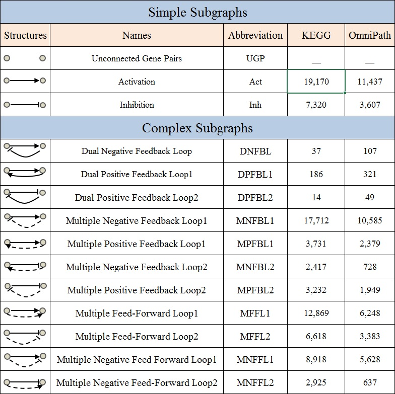

Table1

$~$

$~$

# Results

$~$  
$~$

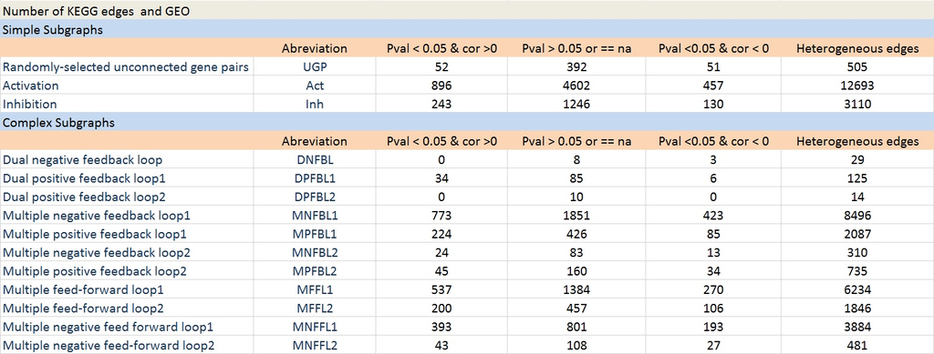

Table2

$~$

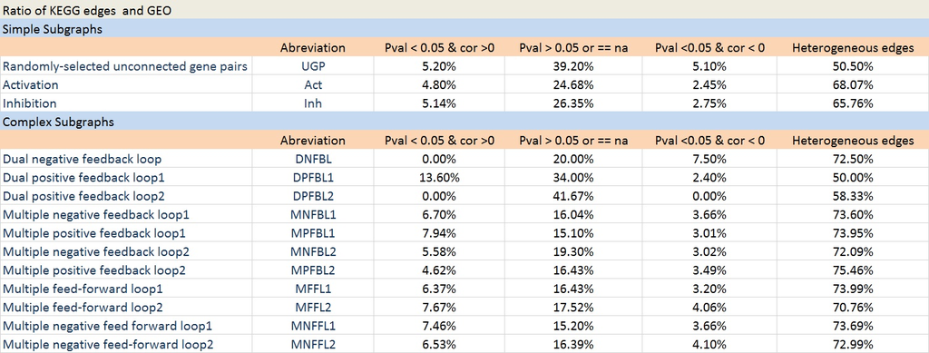

Table3

$~$

$~$

$~$

$~$

$~$